# Proyecto_Final_Portafolios

**Introducción**

El objetivo de este documento es ayudar a seleccionar activos financieros que integrarán un portafolio de inversión, considerando el entorno económico, las características, y las métricas fundamentales que respaldan el desempeño de cada uno de los activos que lo conformarán. Esta primera fase busca convencer al comité de inversión sobre la solidez y pertinencia de cada instrumento seleccionado, tomando en cuenta tanto los aspectos cuantitativos (métricas financieras, rentabilidad, crecimiento, margen operativo) como cualitativos (estrategia corporativa, liderazgo, sostenibilidad y proyección sectorial).

El portafolio está diseñado para un perfil de inversionista adverso al riesgo, que prioriza la preservación del capital, la estabilidad y un crecimiento sostenido en el largo plazo.

El horizonte de inversión recomendado es de quince años, con rebalanceo anual para mantener la diversificación y ajustar las ponderaciones de acuerdo con las condiciones del mercado.

Los cinco activos y el índice analizados en esta sección pertenecen a empresas de gran capitalización y relevancia global:

- Apple Inc. (AAPL): Sector Tecnología de la Información.
- Amazon.com, Inc. (AMZN): Sector Consumo Discrecional / E-commerce.
- Alphabet Inc. (GOOGL): Sector Comunicación y Tecnología.
- JP Morgan Chase & Co. (JPM): Sector Financiero / banca.
- Eli Lily & Co. (LLY): Sector Salud / Farmacéutico.

Estas compañías fueron seleccionadas por su liderazgo global, fundamentos sólidos, bajo nivel de endeudamiento y capacidad comprobada para mantener rendimientos positivos incluso en entornos económicos adversos.

```python
# Importar librerías
import numpy as np
import pandas as pd
import yfinance as yf
import datetime
import seaborn as sns

import matplotlib.pyplot as plt
```

```python
tickers = ['AAPL', 'AMZN', 'GOOGL', 'JPM', 'LLY', 'BND', 'SPLV']
```

```
Matriz de Correlación de Activos:
Ticker      AAPL      AMZN       BND     GOOGL       JPM       LLY      SPLV
Ticker
AAPL    1.000000  0.486444  0.045631  0.542847  0.394009  0.260698  0.498656
AMZN    0.486444  1.000000  0.046628  0.594201  0.321874  0.220024  0.374776
BND     0.045631  0.046628  1.000000  0.041842 -0.116431  0.038327  0.112574
GOOGL   0.542847  0.594201  0.041842  1.000000  0.409032  0.269376  0.467866
JPM     0.394009  0.321874 -0.116431  0.409032  1.000000  0.275330  0.615416
LLY     0.260698  0.220024  0.038327  0.269376  0.275330  1.000000  0.450092
SPLV    0.498656  0.374776  0.112574  0.467866  0.615416  0.450092  1.000000
```

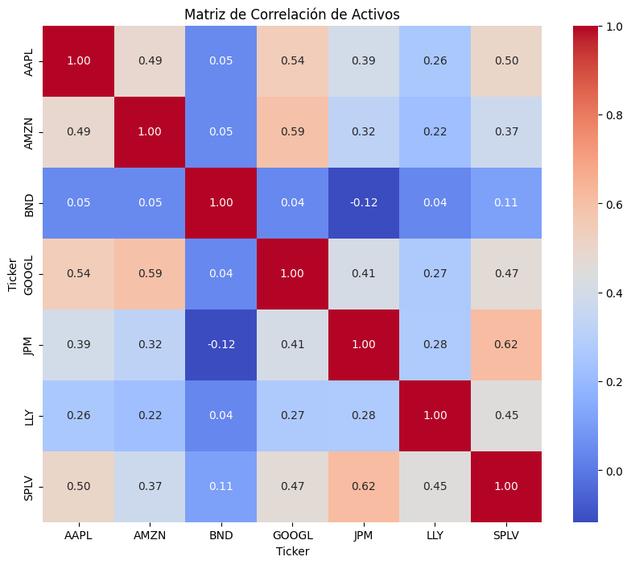

```python
# Descargar datos históricos de precios
data1 = yf.download(tickers, start='2010-01-01', end='2025-11-24')['Close']

# Calcular los rendimientos diarios
returns = data1.pct_change().dropna()

# Calcular la matriz de correlación
correlation_matrix = returns.corr()

# Mostrar la matriz de correlación
print("Matriz de Correlación de Activos:")
print(correlation_matrix)

# Gráfica
plt.figure(figsize=(10, 8))
sns.heatmap(correlation_matrix, annot=True, cmap='coolwarm', fmt=".2f")
plt.title('Matriz de Correlación de Activos')
plt.show()
```

### **Earnings Per Share (EPS)**

Múltiplio financiero que nos indica el beneficio por acción que tiene una compañía, en teoría, indica la cantidad de ingresos que le corresponde a cada inversionista dado su número de acciones, las empresas con una ventaja competitiva a largo plazo siempre muestran EPS estables y positivos a lo largo de 3-10 años y en constante crecimiento.

$$EPS = \frac{Income}{Shares}$$

- Cuanto dinero le corresponde a cada acción

```python
info_aapl = yf.Ticker("AAPL") #Activa
info_amzn = yf.Ticker("AMZN") #Activa
info_goog = yf.Ticker("GOOGL") #Activa
info_jpm = yf.Ticker("JPM") #Activa
info_lly = yf.Ticker("LLY") #Activa
info_bnd = yf.Ticker("BND") #Pasiva
info_splv = yf.Ticker("SPLV") #Pasiva
```

### Activa

```python
# --- AAPL ---
balance_aapl = info_aapl.balance_sheet.iloc[:,:-1]
income_aapl = info_aapl.incomestmt.iloc[:,:-1]

# --- AMZN ---
balance_amzn = info_amzn.balance_sheet.iloc[:,:-1]
income_amzn = info_amzn.incomestmt.iloc[:,:-1]

# --- GOOGL ---
balance_goog = info_goog.balance_sheet.iloc[:,:-1]
income_goog = info_goog.incomestmt.iloc[:,::-1]

# --- JPM ---
balance_jpm = info_jpm.balance_sheet.iloc[:,:-1]
income_jpm = info_jpm.incomestmt.iloc[:,:-1]

# --- LLY ---
balance_lly = info_lly.balance_sheet.iloc[:,:-1]
income_lly = info_lly.incomestmt.iloc[:,:-1]
```

```python
net_income_aapl = income_aapl.loc['Net Income Common Stockholders']
net_income_amzn = income_amzn.loc['Net Income Common Stockholders']
net_income_goog = income_goog.loc['Net Income Common Stockholders']
net_income_jpm  = income_jpm.loc['Net Income Common Stockholders']
net_income_lly  = income_lly.loc['Net Income Common Stockholders']
#net_income_bnd  = income_bnd.loc['Net Income Common Stockholders']
#net_income_splv = income_splv.loc['Net Income Common Stockholders']
```

```python
n_shares_aapl = balance_aapl.loc['Ordinary Shares Number']
n_shares_amzn = balance_amzn.loc['Ordinary Shares Number']
n_shares_goog = balance_goog.loc['Ordinary Shares Number']
n_shares_jpm  = balance_jpm.loc['Ordinary Shares Number']
n_shares_lly  = balance_lly.loc['Ordinary Shares Number']
#n_shares_bnd  = balance_bnd.loc['Ordinary Shares Number']
#n_shares_splv = balance_splv.loc['Ordinary Shares Number']
```

```python
# EPS
eps_aapl = net_income_aapl / n_shares_aapl
eps_amzn = net_income_amzn / n_shares_amzn
eps_goog = net_income_goog / n_shares_goog
eps_jpm  = net_income_jpm  / n_shares_jpm
eps_lly  = net_income_lly  / n_shares_lly
```

### Pasiva

#### SPLV

```python
import yfinance as yf

# --- TOP 10 HOLDINGS SPLV (Activas) ---
info_ato = yf.Ticker("ATO")   # Atmos Energy Corporation
info_evrg = yf.Ticker("EVRG") # Evergy, Inc.
info_wec = yf.Ticker("WEC")   # WEC Energy Group, Inc.
info_tjx = yf.Ticker("TJX")   # The TJX Companies, Inc.
info_o   = yf.Ticker("O")     # Realty Income Corporation
info_cms = yf.Ticker("CMS")   # CMS Energy Corporation
info_ppl = yf.Ticker("PPL")   # PPL Corporation
info_dte = yf.Ticker("DTE")   # DTE Energy Company
info_jnj = yf.Ticker("JNJ")   # Johnson & Johnson
info_aee = yf.Ticker("AEE")   # Ameren Corporation


# --- ATO ---
balance_ato = info_ato.balance_sheet.iloc[:, :-1]
income_ato  = info_ato.incomestmt.iloc[:, :-1]

# --- EVRG ---
balance_evrg = info_evrg.balance_sheet.iloc[:, :-1]
income_evrg  = info_evrg.incomestmt.iloc[:, :-1]

# --- WEC ---
balance_wec = info_wec.balance_sheet.iloc[:, :-1]
income_wec  = info_wec.incomestmt.iloc[:, :-1]

# --- TJX ---
balance_tjx = info_tjx.balance_sheet.iloc[:, :-1]
income_tjx  = info_tjx.incomestmt.iloc[:, :-1]

# --- O ---
balance_o = info_o.balance_sheet.iloc[:, :-1]
income_o  = info_o.incomestmt.iloc[:, :-1]

# --- CMS ---
balance_cms = info_cms.balance_sheet.iloc[:, :-1]
income_cms  = info_cms.incomestmt.iloc[:, :-1]

# --- PPL ---
balance_ppl = info_ppl.balance_sheet.iloc[:, :-1]
income_ppl  = info_ppl.incomestmt.iloc[:, :-1]

# --- DTE ---
balance_dte = info_dte.balance_sheet.iloc[:, :-1]
income_dte  = info_dte.incomestmt.iloc[:, :-1]

# --- JNJ ---
balance_jnj = info_jnj.balance_sheet.iloc[:, :-1]
income_jnj  = info_jnj.incomestmt.iloc[:, :-1]

# --- AEE ---
balance_aee = info_aee.balance_sheet.iloc[:, :-1]
income_aee  = info_aee.incomestmt.iloc[:, :-1]
```

```python
net_income_ato  = income_ato.loc['Net Income Common Stockholders']
net_income_evrg = income_evrg.loc['Net Income Common Stockholders']
net_income_wec  = income_wec.loc['Net Income Common Stockholders']
net_income_tjx  = income_tjx.loc['Net Income Common Stockholders']
net_income_o    = income_o.loc['Net Income Common Stockholders']
net_income_cms  = income_cms.loc['Net Income Common Stockholders']
net_income_ppl  = income_ppl.loc['Net Income Common Stockholders']
net_income_dte  = income_dte.loc['Net Income Common Stockholders']
net_income_jnj  = income_jnj.loc['Net Income Common Stockholders']
net_income_aee  = income_aee.loc['Net Income Common Stockholders']
```

```python
n_shares_ato  = balance_ato.loc['Ordinary Shares Number']
n_shares_evrg = balance_evrg.loc['Ordinary Shares Number']
n_shares_wec  = balance_wec.loc['Ordinary Shares Number']
n_shares_tjx  = balance_tjx.loc['Ordinary Shares Number']
n_shares_o    = balance_o.loc['Ordinary Shares Number']
n_shares_cms  = balance_cms.loc['Ordinary Shares Number']
n_shares_ppl  = balance_ppl.loc['Ordinary Shares Number']
n_shares_dte  = balance_dte.loc['Ordinary Shares Number']
n_shares_jnj  = balance_jnj.loc['Ordinary Shares Number']
n_shares_aee  = balance_aee.loc['Ordinary Shares Number']
```

```python
eps_ato  = net_income_ato  / n_shares_ato
eps_evrg = net_income_evrg / n_shares_evrg
eps_wec  = net_income_wec  / n_shares_wec
eps_tjx  = net_income_tjx  / n_shares_tjx
eps_o    = net_income_o    / n_shares_o
eps_cms  = net_income_cms  / n_shares_cms
eps_ppl  = net_income_ppl  / n_shares_ppl
eps_dte  = net_income_dte  / n_shares_dte
eps_jnj  = net_income_jnj  / n_shares_jnj
eps_aee  = net_income_aee  / n_shares_aee
```

### **Price Earnings Ratio (PER)**

El fundamental más importante para Graham y Buffet, indica cuántas veces se está pagando el beneficio neto anual de una empresa determinada al comprar una acción de esta, es decir, que tan cara o barata esta una acción, en función de su utilidad real y cuánto cuesta comprar una parte de la empresa. También indica el número de veces que el beneficio neto está contenida en el precio de la acción.

Graham recomienda nunca comprar una acción cara o sobrevaluada, por lo que, sin importar si la empresa es muy buena, nunca se recomienda comprar cuando su PER es mayor a 25, cabe destacar, que el PER fluctúa junto con el mercado por eso en mercados bajistas, siempre se encuentra un mayor número de empresas a buen precio y en mercados alcistas es más difícil encontrarlas, pero siempre hay.

$$PER = \frac{Price}{Income/Shares} = \frac{Price}{Earnings Per Share}$$

### Activa

```python
# Bajar un precio en una fecha dada
def get_historical_price(ticker: str, start: str):
    end = start+datetime.timedelta(days=4)
    price=pd.DataFrame(yf.Ticker(ticker).history(start=start, end=end)["Close"])
    return price.iloc[0, 0]
```

```python
list_aapl = list(income_aapl.columns)
list_amzn = list(income_amzn.columns)
list_goog = list(income_goog.columns)
list_jpm  = list(income_jpm.columns)
list_lly  = list(income_lly.columns)
```

```python
prices_aapl = [get_historical_price("AAPL", date) for date in list_aapl]
prices_amzn = [get_historical_price("AMZN", date) for date in list_amzn]
prices_goog = [get_historical_price("GOOGL", date) for date in list_goog]
prices_jpm  = [get_historical_price("JPM",  date) for date in list_jpm]
prices_lly  = [get_historical_price("LLY",  date) for date in list_lly]
```

```python
# PER
per_aapl = prices_aapl / eps_aapl
per_amzn = prices_amzn / eps_amzn
per_goog = prices_goog / eps_goog
per_jpm = prices_jpm / eps_jpm
per_lly = prices_lly / eps_lly
```

### Pasiva

#### SPLV

```python
list_ato  = list(income_ato.columns)
list_evrg = list(income_evrg.columns)
list_wec  = list(income_wec.columns)
list_tjx  = list(income_tjx.columns)
list_o    = list(income_o.columns)
list_cms  = list(income_cms.columns)
list_ppl  = list(income_ppl.columns)
list_dte  = list(income_dte.columns)
list_jnj  = list(income_jnj.columns)
list_aee  = list(income_aee.columns)
```

```python
prices_ato  = [get_historical_price("ATO",  date) for date in list_ato]
prices_evrg = [get_historical_price("EVRG", date) for date in list_evrg]
prices_wec  = [get_historical_price("WEC",  date) for date in list_wec]
prices_tjx  = [get_historical_price("TJX",  date) for date in list_tjx]
prices_o    = [get_historical_price("O",    date) for date in list_o]
prices_cms  = [get_historical_price("CMS",  date) for date in list_cms]
prices_ppl  = [get_historical_price("PPL",  date) for date in list_ppl]
prices_dte  = [get_historical_price("DTE",  date) for date in list_dte]
prices_jnj  = [get_historical_price("JNJ",  date) for date in list_jnj]
prices_aee  = [get_historical_price("AEE",  date) for date in list_aee]
```

```python
per_ato  = pd.Series(prices_ato, index=list_ato) / eps_ato
per_evrg = pd.Series(prices_evrg, index=list_evrg) / eps_evrg
per_wec  = pd.Series(prices_wec, index=list_wec) / eps_wec[list_wec]
per_tjx  = pd.Series(prices_tjx, index=list_tjx) / eps_tjx
per_o    = pd.Series(prices_o, index=list_o) / eps_o
per_cms  = pd.Series(prices_cms, index=list_cms) / eps_cms
per_ppl  = pd.Series(prices_ppl, index=list_ppl) / eps_ppl
per_dte  = pd.Series(prices_dte, index=list_dte) / eps_dte
per_jnj  = pd.Series(prices_jnj, index=list_jnj) / eps_jnj[list_jnj]
per_aee  = pd.Series(prices_aee, index=list_aee) / eps_aee[list_aee]
```

### **EBITDA**

Beneficio "*real*" de la empresa antes de amortizaciones, depreciaciones e impuestos.

Es importante que este sea positivo y se compare contra el *benchmark* de mercado u otras empresas del mismo giro. Se utiliza debido a que, en teoría, las amortizaciones y depreciaciones no son un "egreso real", debido a que no sale dinero del bolsillo de una empresa, y por eso hay que tenerlas en cuenta para ver las utilidades de una empresa

- *Disclaimer:* Cabe destacar, que, aunque mucha gente toma el EBITDA como una métrica importante para el análisis fundamental, tanto Graham como Buffet recomiendan no usarla, ya que, si bien es correcto que en el momento no es un egreso real, la maquinaria, planta y equipo de una empresa esta acabando su vida útil, y cuando esta llegue a su fin, la empresa tendrá que desembolsar una gran cantidad de dinero para seguir operando.

### Activa

```python
# --- EBITDA por empresa ---
aapl_ebitda = income_aapl.loc["Normalized EBITDA"]
amzn_ebitda = income_amzn.loc["Normalized EBITDA"]
goog_ebitda = income_goog.loc["Normalized EBITDA"]
#jpm_ebitda  = income_jpm.loc["Normalized EBITDA"]
lly_ebitda  = income_lly.loc["Normalized EBITDA"]
```

### Pasiva

```python
# --- EBITDA por empresa (Top 10 SPLV) ---
ato_ebitda  = income_ato.loc["Normalized EBITDA"]
evrg_ebitda = income_evrg.loc["Normalized EBITDA"]
wec_ebitda  = income_wec.loc["Normalized EBITDA"]
tjx_ebitda  = income_tjx.loc["Normalized EBITDA"]
o_ebitda    = income_o.loc["Normalized EBITDA"]
cms_ebitda  = income_cms.loc["Normalized EBITDA"]
ppl_ebitda  = income_ppl.loc["Normalized EBITDA"]
dte_ebitda  = income_dte.loc["Normalized EBITDA"]
jnj_ebitda  = income_jnj.loc["Normalized EBITDA"]
aee_ebitda  = income_aee.loc["Normalized EBITDA"]
```

### **Price Book Value (PBV)**

Múltiplo financiero que relaciona el Market Cap y el valor en libros. Se obtiene dividiendo el Market Cap entre el valor en libros de la empresa.

El valor contable, es el valor neto que presenta su contabilidad, esto es, el valor de sus recursos propios, o lo que es lo mismo el pasivo total menos el pasivo exigible.

El precio valor libro se usa para medir si una acción se valora correctamente:

- Una relación precio valor contable de uno significa que el precio de las acciones se cotiza en línea con el valor en libros de la empresa. En otras palabras, el precio de las acciones se consideraría razonablemente valorado, estrictamente desde el punto de vista de la relación precio valor en libros.
- Una empresa con una relación precio valor en libros alta podría significar que el precio de las acciones está sobrevalorado
- Una empresa con una relación precio valor contable más baja podría estar infravalorada.

Sin embargo, la relación precio valor contable debe compararse con empresas del mismo sector. La proporción es más alta para algunas industrias que para otras. Por lo tanto, es importante compararlo con empresas con una composición similar de activos y pasivos.

También podría considerarse como un múltiplo que nos indica cuantas veces el mercado sobre-valora o infra-valora una empresa en función de sus expectativas y lo que realmente vale.

### Activa

```python
market_cap_aapl = prices_aapl*n_shares_aapl
market_cap_amzn = prices_amzn*n_shares_amzn
market_cap_goog = prices_goog*n_shares_goog
market_cap_jpm = prices_jpm*n_shares_jpm
market_cap_lly = prices_lly*n_shares_lly
```

```python
book_value_aapl = balance_aapl.loc['Tangible Book Value']
book_value_amzn = balance_amzn.loc['Tangible Book Value']
book_value_goog = balance_goog.loc['Tangible Book Value']
book_value_jpm = balance_jpm.loc['Tangible Book Value']
book_value_lly = balance_lly.loc['Tangible Book Value']
```

```python
pbv_aapl = market_cap_aapl / book_value_aapl
pbv_amzn = market_cap_amzn / book_value_amzn
pbv_goog = market_cap_goog / book_value_goog
pbv_jpm = market_cap_jpm / book_value_jpm
pbv_lly = market_cap_lly / book_value_lly
```

### Pasiva

```python
market_cap_ato  = pd.Series(prices_ato, index=list_ato) * n_shares_ato
market_cap_evrg = pd.Series(prices_evrg, index=list_evrg) * n_shares_evrg
market_cap_wec  = pd.Series(prices_wec, index=list_wec) * n_shares_wec
market_cap_tjx  = pd.Series(prices_tjx, index=list_tjx) * n_shares_tjx
market_cap_o    = pd.Series(prices_o, index=list_o) * n_shares_o
market_cap_cms  = pd.Series(prices_cms, index=list_cms) * n_shares_cms
market_cap_ppl  = pd.Series(prices_ppl, index=list_ppl) * n_shares_ppl
market_cap_dte  = pd.Series(prices_dte, index=list_dte) * n_shares_dte
market_cap_jnj  = pd.Series(prices_jnj, index=list_jnj) * n_shares_jnj
market_cap_aee  = pd.Series(prices_aee, index=list_aee) * n_shares_aee
```

```python
book_value_ato  = balance_ato.loc["Tangible Book Value"]
book_value_evrg = balance_evrg.loc["Tangible Book Value"]
book_value_wec  = balance_wec.loc["Tangible Book Value"]
book_value_tjx  = balance_tjx.loc["Tangible Book Value"]
book_value_o    = balance_o.loc["Tangible Book Value"]
book_value_cms  = balance_cms.loc["Tangible Book Value"]
book_value_ppl  = balance_ppl.loc["Tangible Book Value"]
book_value_dte  = balance_dte.loc["Tangible Book Value"]
book_value_jnj  = balance_jnj.loc["Tangible Book Value"]
book_value_aee  = balance_aee.loc["Tangible Book Value"]
```

```python
pbv_ato  = market_cap_ato  / book_value_ato
pbv_evrg = market_cap_evrg / book_value_evrg
pbv_wec  = market_cap_wec  / book_value_wec
pbv_tjx  = market_cap_tjx  / book_value_tjx
pbv_o    = market_cap_o    / book_value_o
pbv_cms  = market_cap_cms  / book_value_cms
pbv_ppl  = market_cap_ppl  / book_value_ppl
pbv_dte  = market_cap_dte  / book_value_dte
pbv_jnj  = market_cap_jnj  / book_value_jnj
pbv_aee  = market_cap_aee  / book_value_aee
```

### **Solvency**

Múltiplo financiero que nos indica que tan solvente es una empresa para hacer frente a sus obligaciones, es decir, que tantos activos tiene contra los pasivos, esta se obtiene de la siguiente forma:

$$Solvency = \frac{Assets}{Liabilities}$$

### Activo

```python
solv_aapl = balance_aapl.loc["Total Assets"] / balance_aapl.loc["Total Liabilities Net Minority Interest"]
solv_amzn = balance_amzn.loc["Total Assets"] / balance_amzn.loc["Total Liabilities Net Minority Interest"]
solv_goog = balance_goog.loc["Total Assets"] / balance_goog.loc["Total Liabilities Net Minority Interest"]
solv_jpm  = balance_jpm .loc["Total Assets"] / balance_jpm .loc["Total Liabilities Net Minority Interest"]
solv_lly  = balance_lly .loc["Total Assets"] / balance_lly .loc["Total Liabilities Net Minority Interest"]
```

### Pasiva

```python
solv_ato  = balance_ato.loc["Total Assets"] / balance_ato.loc["Total Liabilities Net Minority Interest"]
solv_evrg = balance_evrg.loc["Total Assets"] / balance_evrg.loc["Total Liabilities Net Minority Interest"]
solv_wec  = balance_wec.loc["Total Assets"] / balance_wec.loc["Total Liabilities Net Minority Interest"]
solv_tjx  = balance_tjx.loc["Total Assets"] / balance_tjx.loc["Total Liabilities Net Minority Interest"]
solv_o    = balance_o.loc["Total Assets"] / balance_o.loc["Total Liabilities Net Minority Interest"]
solv_cms  = balance_cms.loc["Total Assets"] / balance_cms.loc["Total Liabilities Net Minority Interest"]
solv_ppl  = balance_ppl.loc["Total Assets"] / balance_ppl.loc["Total Liabilities Net Minority Interest"]
solv_dte  = balance_dte.loc["Total Assets"] / balance_dte.loc["Total Liabilities Net Minority Interest"]
solv_jnj  = balance_jnj.loc["Total Assets"] / balance_jnj.loc["Total Liabilities Net Minority Interest"]
solv_aee  = balance_aee.loc["Total Assets"] / balance_aee.loc["Total Liabilities Net Minority Interest"]
```

### **Return On Shareholder Equity (ROE)**

Mide el porcentaje de rentabilidad que se puede ofrecer dado el Equity dado, es decir, que tanto provecho se le esta sacando al Capital que se tiene. Básicamente, expone las ganancias que los accionistas están obteniendo.

$$ROE = \frac{Income}{Equity} * 100$$

El resultado esta expresado en %.

### Activo

```python
roe_aapl = (net_income_aapl / balance_aapl.loc['Common Stock Equity'])*100
roe_amzn = (net_income_amzn / balance_amzn.loc['Common Stock Equity'])*100
roe_goog = (net_income_goog / balance_goog.loc['Common Stock Equity'])*100
roe_jpm  = (net_income_jpm / balance_jpm.loc['Common Stock Equity'])*100
roe_lly  = (net_income_lly / balance_lly.loc['Common Stock Equity'])*100
```

### Pasivo

```python
roe_ato  = (net_income_ato  / balance_ato.loc['Common Stock Equity']) * 100
roe_evrg = (net_income_evrg / balance_evrg.loc['Common Stock Equity']) * 100
roe_wec  = (net_income_wec  / balance_wec.loc['Common Stock Equity']) * 100
roe_tjx  = (net_income_tjx  / balance_tjx.loc['Common Stock Equity']) * 100
roe_o    = (net_income_o    / balance_o.loc['Common Stock Equity'])   * 100
roe_cms  = (net_income_cms  / balance_cms.loc['Common Stock Equity']) * 100
roe_ppl  = (net_income_ppl  / balance_ppl.loc['Common Stock Equity']) * 100
roe_dte  = (net_income_dte  / balance_dte.loc['Common Stock Equity']) * 100
roe_jnj  = (net_income_jnj  / balance_jnj.loc['Common Stock Equity']) * 100
roe_aee  = (net_income_aee  / balance_aee.loc['Common Stock Equity']) * 100
```

### Márgenes de Beneficio Sólidos

El **profit margin** o margen de beneficio antes de impuestos de una empresa se calcula restando todos los gastos de las ventas (excepto impuestos) y dividiendo por las ventas. Es una métrica importante a considerar porque una empresa puede tener un crecimiento fantástico en ventas con ganancias pobres, lo que podría indicar que la administración no está controlando costos y ingresos.

$$PM = \frac{\text{Income before Tax}}{\text{Sales or Gross Revenue}}$$

El porcentaje de profit margin considerado "bueno" depende de la industria, ya que los márgenes varían significativamente según el sector

### Activo

```python
pm_aapl = net_income_aapl/income_aapl.loc["Total Revenue"]*100
pm_amzn = net_income_amzn/income_amzn.loc["Total Revenue"]*100
pm_goog = net_income_goog/income_goog.loc["Total Revenue"]*100
pm_jpm  = net_income_jpm/income_jpm.loc["Total Revenue"]*100
pm_lly = net_income_lly/income_lly.loc["Total Revenue"]*100
```

### Pasivo

```python
pm_ato  = net_income_ato  / income_ato.loc["Total Revenue"]  * 100
pm_evrg = net_income_evrg / income_evrg.loc["Total Revenue"] * 100
pm_wec  = net_income_wec  / income_wec.loc["Total Revenue"]  * 100
#pm_tjx  = net_income_tjx  / income_tjx.loc["Total Revenue"]  * 100
pm_o    = net_income_o    / income_o.loc["Total Revenue"]    * 100
pm_cms  = net_income_cms  / income_cms.loc["Total Revenue"]  * 100
pm_ppl  = net_income_ppl  / income_ppl.loc["Total Revenue"]  * 100
pm_dte  = net_income_dte  / income_dte.loc["Total Revenue"]  * 100
pm_jnj  = net_income_jnj  / income_jnj.loc["Total Revenue"]  * 100
pm_aee  = net_income_aee  / income_aee.loc["Total Revenue"]  * 100
```

## Resultados analisis fundamental

```python
from IPython.display import display, Markdown

def to_year_index(series):
    new_index = series.index.astype(str).str[:4]
    series.index = new_index
    return series
```

### Apple

Apple Inc. ha evolucionado desde sus inicios como fabricante de computadoras personales hasta convertirse en una empresa líder en el sector tecnológico, con una amplia gama de productos y servicios. Entre sus principales líneas de negocio se encuentran el iPhone, Mac, iPad, Apple Watch y servicios como Apple Music, iCloud, Apple TV+, Apple Pay y la App Store. Esta integración le permite generar ingresos diversificados y construir lealtad por parte de sus clientes. En el segundo trimestre fiscal de 2025, Apple reportó ingresos por 95.4 mil millones de dólares, un incremento del 5 % interanual, y una utilidad por acción diluida de 1.65 USD, reflejando su capacidad de mantener la rentabilidad incluso en entornos económicos restrictivos (Apple Inc., 2025). Su margen bruto se mantiene alrededor del 45 %, uno de los más altos de la industria, impulsado por el control sobre su cadena de suministro y la venta de productos de alto valor agregado. Además, Apple cuenta con un flujo de caja libre robusto que le permite financiar innovaciones, recomprar acciones y pagar dividendos sin comprometer su estabilidad financiera. Su nivel de deuda es moderado y su ROE supera el 140 %, sustentado en eficiencia operativa y políticas activas de recompra. Para un inversionista adverso al riesgo, Apple representa una inversión defensiva dentro del sector tecnológico. Combina innovación constante, generación de efectivo estable y bajo riesgo crediticio. Su transición hacia servicios recurrentes y la incursión en inteligencia artificial y realidad aumentada consolidan su posición como una empresa de bajo riesgo estructural con potencial de crecimiento moderado.

**Análisis del sector: Tecnología de la Información (IT)**

El sector de Tecnología de la Información engloba empresas dedicadas al desarrollo de hardware, software, servicios digitales, semiconductores y soluciones de inteligencia artificial. Este sector es uno de los principales motores del crecimiento económico mundial, al impulsar la productividad, la digitalización y la innovación. En Estados Unidos, el mercado de servicios de TI se valoró en más de 400 mil millones de dólares en 2023 y se proyecta un crecimiento anual compuesto superior al 7 % hacia 2030 (Grand View Research, 2025). Las tendencias actuales incluyen la automatización, la computación en la nube, la ciberseguridad y la inteligencia artificial, todos segmentos donde Apple tiene presencia directa o indirecta. Desde una perspectiva de riesgo, el sector puede experimentar volatilidad en fases de ajuste monetario o sobrevaloración de activos tecnológicos. No obstante, las empresas consolidadas, como Apple ofrecen una exposición más estable, con modelos de negocio probados y gran liquidez de mercado.

```python
eps_aapl_y     = to_year_index(eps_aapl.copy())
per_aapl_y     = to_year_index(per_aapl.copy())
ebitda_aapl_y  = to_year_index(aapl_ebitda.copy())
pbv_aapl_y     = to_year_index(pbv_aapl.copy())
solv_aapl_y    = to_year_index(solv_aapl.copy())
roe_aapl_y     = to_year_index(roe_aapl.copy())
```

```python
eps_aapl_y     = eps_aapl_y.groupby(eps_aapl_y.index).last()
per_aapl_y     = per_aapl_y.groupby(per_aapl_y.index).last()
ebitda_aapl_y  = ebitda_aapl_y.groupby(ebitda_aapl_y.index).last()
pbv_aapl_y     = pbv_aapl_y.groupby(pbv_aapl_y.index).last()
solv_aapl_y    = solv_aapl_y.groupby(solv_aapl_y.index).last()
roe_aapl_y     = roe_aapl_y.groupby(roe_aapl_y.index).last()
```

```python
display(Markdown("## Apple – Fundamental Metrics"))

aapl_fundamentals = pd.DataFrame({
    "EPS"      : eps_aapl_y,
    "PER"      : per_aapl_y,
    "EBITDA"   : ebitda_aapl_y,
    "PBV"      : pbv_aapl_y,
    "Solvency" : solv_aapl_y,
    "ROE"      : roe_aapl_y
})

display(aapl_fundamentals)
```

Apple – Fundamental Metrics

|  | EPS | PER | EBITDA | PBV | Solvency | ROE |
| --- | --- | --- | --- | --- | --- | --- |
| 2022 | 6.259822 | 21.713175 | 1.305410e+11 | 42.766025 | 1.167742 | 196.958873 |
| 2023 | 6.237596 | 27.558372 | 1.258200e+11 | 43.012009 | 1.213974 | 156.076015 |
| 2024 | 6.200789 | 37.365572 | 1.346610e+11 | 61.501305 | 1.184885 | 164.593503 |
| 2025 | 7.581942 | 33.551221 | 1.447480e+11 | 50.968660 | 1.258252 | 151.912983 |

Apple muestra un desempeño sólido entre 2022 y 2025, aunque con señales mixtas. El EPS y el EBITDA se mantienen relativamente estables hasta 2024 y repuntan en 2025, reflejando una recuperación real en utilidades y en la operación del negocio. Las valuaciones, en cambio, se encarecen bastante: tanto el PER como el PBV suben de manera importante, lo que indica que el mercado ha estado pagando precios elevados por la acción. La solvencia mejora ligeramente y se mantiene cómoda en todos los años, señal de una estructura financiera muy fuerte. El ROE sigue siendo excepcionalmente alto, aunque con una leve tendencia a la baja, influenciado por el uso de deuda y las recompras de acciones. En conjunto, Apple continúa siendo una empresa muy rentable y financieramente robusta, pero cotiza a múltiplos altos que sugieren que buena parte de su valor ya está reflejado en el precio.

### Amazon

Amazon.com, Inc., fundada en 1994, es una de las corporaciones más influyentes del mundo en comercio electrónico, servicios en la nube y entretenimiento digital. Su modelo de negocio diversificado, que combina retail global, infraestructura logística, suscripción (Amazon Prime), computación en la nube (AWS) y publicidad digital, le permite mitigar riesgos y mantener crecimiento sostenido. En el primer trimestre de 2025, la empresa reportó ventas de 155.7 mil millones USD, un aumento del 9 % interanual, y en el segundo trimestre alcanzó los 167.7 mil millones USD, impulsadas por un incremento del 17.5 % en Amazon Web Services (Amazon.com, Inc., 2025). El negocio de AWS se ha convertido en el principal motor de rentabilidad de la empresa, aportando la mayor parte de sus beneficios operativos y dotándola de una fuente de ingresos estable y predecible. Amazon presenta una posición financiera saludable, con un apalancamiento controlado, liquidez elevada y márgenes en expansión. Para un perfil conservador, su atractivo radica en su capacidad de generar flujos constantes y resistir ciclos económicos adversos gracias a su escala global y a la diversificación de ingresos. Los riesgos principales están ligados al consumo global, la competencia en e-commerce, la presión regulatoria y el costo de infraestructura. Aun así, la eficiencia logística y la inversión sostenida en inteligencia artificial y automatización fortalecen su perfil de bajo riesgo relativo.

**Análisis del sector: Consumo Discrecional / E-commerce**

El sector de Consumo Discrecional agrupa empresas que ofrecen bienes y servicios no esenciales, como retail, ocio, moda, e-commerce y entretenimiento. Su desempeño está estrechamente vinculado a factores macroeconómicos como la confianza del consumidor, el empleo y la renta disponible. Dentro de este sector, el comercio electrónico ha sido el principal impulsor del crecimiento en la última década. En Estados Unidos, se estima que el mercado del e-commerce alcanzará 1.25 billones USD en 2025 y superará los 2 billones USD para 2030, con un crecimiento anual proyectado del 10.7 % (Mordor Intelligence, 2025). Para los inversionistas conservadores, el sector presenta riesgos asociados a la sensibilidad económica y la competencia. Sin embargo, compañías de gran escala, como Amazon, cuentan con la infraestructura y la diversificación necesarias para ofrecer exposición al crecimiento digital con riesgo moderado, especialmente por su liderazgo en la nube y sus negocios complementarios.

```python
eps_amzn_y     = to_year_index(eps_amzn.copy())
per_amzn_y     = to_year_index(per_amzn.copy())
ebitda_amzn_y  = to_year_index(amzn_ebitda.copy())
pbv_amzn_y     = to_year_index(pbv_amzn.copy())
solv_amzn_y    = to_year_index(solv_amzn.copy())
roe_amzn_y     = to_year_index(roe_amzn.copy())

eps_amzn_y     = eps_amzn_y.groupby(eps_amzn_y.index).last()
per_amzn_y     = per_amzn_y.groupby(per_amzn_y.index).last()
ebitda_amzn_y  = ebitda_amzn_y.groupby(ebitda_amzn_y.index).last()
pbv_amzn_y     = pbv_amzn_y.groupby(pbv_amzn_y.index).last()
solv_amzn_y    = solv_amzn_y.groupby(solv_amzn_y.index).last()
roe_amzn_y     = roe_amzn_y.groupby(roe_amzn_y.index).last()

display(Markdown("## Amazon (AMZN) – Fundamental Metrics"))
amzn_fundamentals = pd.DataFrame({
    "EPS"      : eps_amzn_y,
    "PER"      : per_amzn_y,
    "EBITDA"   : ebitda_amzn_y,
    "PBV"      : pbv_amzn_y,
    "Solvency" : solv_amzn_y,
    "ROE"      : roe_amzn_y
})
display(amzn_fundamentals)
```

Amazon (AMZN) – Fundamental Metrics

|  | EPS | PER | EBITDA | PBV | Solvency | ROE |
| --- | --- | --- | --- | --- | --- | --- |
| 2021 | 3.277407 | 50.868571 | 5.974100e+10 | 14.411329 | 1.489703 | 24.133965 |
| 2022 | -0.265768 | -322.912725 | 5.461800e+10 | 7.345672 | 1.461239 | -1.863835 |
| 2023 | 2.930271 | 51.165920 | 8.828700e+10 | 9.082452 | 1.619288 | 15.071207 |
| 2024 | 5.593128 | 39.224923 | 1.256440e+11 | 9.139021 | 1.843758 | 20.718257 |

Amazon muestra un comportamiento muy volátil entre 2021 y 2024. En 2021 mantiene métricas sólidas, pero en 2022 sufre un deterioro fuerte: el EPS se vuelve negativo y el PER cae a valores extremos porque la empresa registra pérdidas contables, aunque su EBITDA se mantiene alto. A partir de 2023 comienza una recuperación clara. El EPS vuelve a ser positivo y crece de forma significativa hasta 2024, acompañado de un EBITDA que también se expande con fuerza, lo que refleja un repunte real en la eficiencia operativa y la rentabilidad del negocio. La solvencia mejora gradualmente, lo que indica una estructura financiera más estable. El ROE sigue una trayectoria similar: cae de forma abrupta en 2022, pero se recupera en 2023 y 2024 aunque sin llegar a los niveles de 2021. En conjunto, Amazon pasa por un año difícil en 2022, pero después muestra una recuperación consistente en sus fundamentales, apoyada en mayor rentabilidad y fortaleza operativa.

### Google

Alphabet Inc., es una de las compañías más influyentes en el ámbito digital global. Su negocio abarca búsquedas en línea, publicidad digital, servicios de nube (Google Cloud), sistemas operativos (Android), plataformas de video (YouTube) e inteligencia artificial (Gemini, Vertex AI). En el primer trimestre de 2025, Alphabet reportó ingresos por 90.2 mil millones USD, un crecimiento del 12 % interanual, y en el segundo trimestre alcanzó 96.4 mil millones USD, un incremento del 14 % (Alphabet Inc., 2025). Su margen bruto del 56 % y su bajo nivel de endeudamiento la posicionan entre las empresas tecnológicas con mejor perfil financiero. Para un inversionista adverso al riesgo, Alphabet ofrece un equilibrio ideal entre estabilidad y proyección. Combina el liderazgo en publicidad digital con la expansión de servicios en la nube y el desarrollo de IA generativa. Además, su sólida posición de efectivo y su política prudente de reinversión fortalecen su capacidad de resiliencia. Entre los riesgos relevantes destacan la regulación antimonopolio, la competencia en el mercado de IA y la dependencia parcial del negocio publicitario. Aun así, el tamaño, la innovación y la diversificación de Alphabet reducen sustancialmente su riesgo estructural.

**Análisis del sector: Comunicación y Tecnología** El sector de Comunicación y Tecnología agrupa empresas dedicadas a telecomunicaciones, medios digitales, plataformas de internet, publicidad, entretenimiento y redes sociales. Este sector se caracteriza por combinar negocios estables con empresas de crecimiento acelerado impulsadas por la digitalización y el consumo de datos. La demanda de servicios de comunicación digital y contenidos en línea ha crecido exponencialmente en la última década. Según Bloomberg (2025), el sector mantiene un ritmo de expansión de aproximadamente 8 % anual, sustentado en la adopción de inteligencia artificial, el streaming y la monetización de datos. Desde el punto de vista del riesgo, el sector presenta volatilidad asociada a los cambios tecnológicos y la regulación, pero las empresas de gran escala y diversificación como Alphabet, ofrecen una exposición más equilibrada, combinando rendimiento sostenido con bajo riesgo financiero.

```python
eps_goog_y     = to_year_index(eps_goog.copy())
per_goog_y     = to_year_index(per_goog.copy())
ebitda_goog_y  = to_year_index(goog_ebitda.copy())
pbv_goog_y     = to_year_index(pbv_goog.copy())
solv_goog_y    = to_year_index(solv_goog.copy())
roe_goog_y     = to_year_index(roe_goog.copy())

eps_goog_y     = eps_goog_y.groupby(eps_goog_y.index).last()
per_goog_y     = per_goog_y.groupby(per_goog_y.index).last()
ebitda_goog_y  = ebitda_goog_y.groupby(ebitda_goog_y.index).last()
pbv_goog_y     = pbv_goog_y.groupby(pbv_goog_y.index).last()
solv_goog_y    = solv_goog_y.groupby(solv_goog_y.index).last()
roe_goog_y     = roe_goog_y.groupby(roe_goog_y.index).last()

display(Markdown("## Alphabet (GOOGL) – Fundamental Metrics"))
goog_fundamentals = pd.DataFrame({
    "EPS"      : eps_goog_y,
    "PER"      : per_goog_y,
    "EBITDA"   : ebitda_goog_y,
    "PBV"      : pbv_goog_y,
    "Solvency" : solv_goog_y,
    "ROE"      : roe_goog_y
})
display(goog_fundamentals)
```

Alphabet (GOOGL) – Fundamental Metrics

|  | EPS | PER | EBITDA | PBV | Solvency | ROE |
| --- | --- | --- | --- | --- | --- | --- |
| 2021 | 5.741624 | 25.055591 | 9.115700e+10 | 10.994553 | 3.337898 | 30.215590 |
| 2022 | 4.667445 | 18.963168 | 9.167000e+10 | 7.761046 | 3.347361 | 23.413392 |
| 2023 | 5.922552 | 23.169666 | 1.006600e+11 | 4.338754 | 3.381076 | 26.041097 |
| 2024 | 8.199001 | 23.013153 | 1.333200e+11 | 5.991398 | 3.597098 | 30.797578 |

### JPM

JP Morgan Chase & Co es el banco más grande de Estados Unidos y uno de los mayores del mundo, el cual destaca por su solidez, diversificación y buena gestión. Al cierre del 2024, mostró un patrimonio de $345 mil millones de dólares, operando en múltiples líneas de negocio como lo es la banca de inversión, comercial, minorista, pagos y gestión de activos en más de 100 países, lo cual le brinda una ventaja competitiva significativa y difícil de igualar. Liderado por Jamie Dimon, JPM ha mantenido la filosofía de “balance general fortaleza”, priorizando capital y liquidez elevado, dicha filosofía les ha permitido afrontar crisis como la del 2008 y 2020.

Como resultado de ello, en 2024 se registraron utilidades neta récord de $58.5 mil millones de dólares ( +18% anual), un ROE ( Return On Equity ) de 17% y un ROTCE ( Return On Tangible Common Equity ) de 21%, esto indica una rentabilidad sólida y sostenible. Asimismo, su índice CET1 ( Common Equity Tier 1 - mide la capacidad del banco para absorber pérdidas) del 15% y liquidez de $1.4 billones; a su vez, ofrece dividendos anuales de $5 dólares por acción y recompras selectivas, lo cual confirman su perfil conservador y resiliente. Por otro lado, la empresa invierte de manera significativa ( $12 mi millones de dólares anuales ) en tecnología, lo cual refuerza su posición frente a las fintech y está en constante mejora operativa; es decir, la empresa ha logrado controlar sus costos operativos, de tal forma que solo gasta el 55% de sus ingresos en operar, reflejando una gestión eficiente, rentable y disciplina. Si bien la empresa enfrenta los riesgos propios del ciclo crediticio, las tasa de interés y regulación, JMP se mantiene estable con capitalización alta y preparados para neutralizar el riesgo. A raíz de su escala, la gestión ejemplar y su reputación a nivel global, JPM representa una opción sólida para inversionistas conservadores que buscan estabilidad, dividendos y crecimiento sostenido a largo plazo.

**Análisis del sector : Financiero y bancario** El sector financiero, especialmente la banca, ha demostrado ser cíclico pero resiliente a largo plazo. Después de la crisis del 2008, las reformas regulatorias fortalecieron su estabilidad al ser más exigentes con el manejo de capital y liquidez. En la última década, los bancos han alcanzado resultados récord, en 2024 los ingresos globales fueron de aproximadamente $5.5 billones de dólares y con utilidades netas de $1.2 billones de dólares; esto como resultado de la recuperación post-pandemia y las altas tasas de interés. Aunque se espera una moderación de este crecimiento ante la posible disminución de dichos factores, el sector sigue demostrando estabilidad para inversiones de largo plazo. En este contexto, JP Morgan se mantiene como líder en EE.UU y como referente mundial por su rentabilidad y buena gestión; en conjunto, el sector financiero ofrece un crecimiento moderado ligado al desempeño económico y a los rendimientos sostenidos por dividendos con una volatilidad cíclica pero manejable.

```python
eps_jpm_y     = to_year_index(eps_jpm.copy())
per_jpm_y     = to_year_index(per_jpm.copy())
#ebitda_jpm_y  = to_year_index(jpm_ebitda.copy())
pbv_jpm_y     = to_year_index(pbv_jpm.copy())
solv_jpm_y    = to_year_index(solv_jpm.copy())
roe_jpm_y     = to_year_index(roe_jpm.copy())

eps_jpm_y     = eps_jpm_y.groupby(eps_jpm_y.index).last()
per_jpm_y     = per_jpm_y.groupby(per_jpm_y.index).last()
#ebitda_jpm_y  = ebitda_jpm_y.groupby(ebitda_jpm_y.index).last()
pbv_jpm_y     = pbv_jpm_y.groupby(pbv_jpm_y.index).last()
solv_jpm_y    = solv_jpm_y.groupby(solv_jpm_y.index).last()
roe_jpm_y     = roe_jpm_y.groupby(roe_jpm_y.index).last()

display(Markdown("## JPMorgan (JPM) – Fundamental Metrics"))
jpm_fundamentals = pd.DataFrame({
    "EPS"      : eps_jpm_y,
    "PER"      : per_jpm_y,
    #"EBITDA"   : ebitda_jpm_y,
    "PBV"      : pbv_jpm_y,
    "Solvency" : solv_jpm_y,
    "ROE"      : roe_jpm_y
})
display(jpm_fundamentals)
```

JPMorgan (JPM) – Fundamental Metrics

|  | EPS | PER | PBV | Solvency | ROE |
| --- | --- | --- | --- | --- | --- |
| 2021 | 15.795056 | 9.026063 | 2.071783 | 1.085268 | 17.934814 |
| 2022 | 12.232054 | 10.259294 | 1.804422 | 1.086658 | 13.547832 |
| 2023 | 16.602596 | 9.913067 | 2.005346 | 1.092425 | 15.894886 |
| 2024 | 20.327275 | 11.548069 | 2.524392 | 1.094246 | 17.513581 |

### Lly

Eli Lilly Company es una de las farmacéuticas más importantes del mundo, fundada en 1876 y reconocida por su liderazgo en tratamientos para la diabetes, obesidad, oncología, inmunología y alzheimer; opera en más de 90 países y ha demostrado una fuerte orientación hacia la innovación, destinando alrededor de 25% de sus ventas investigación y desarrollo. Tras obtener un crecimiento moderado a inicios del 2020, Lilly presentó un impulso significativo gracias al éxito obtenido de sus nuevos fármacos ( “Mounjaro” y “Zepbound”), los cuales lograron posicionar a la empresa como líder emergente en el mercado de la obesidad y la diabetes tipo 2. No obstante, en 2024 superó su utilidad neta a $10.6 mil millones ( +102%), alcanzó un ROE superior al 70% y márgenes netos del 23%, demostrando una vez más su alta rentabilidad y eficiencia; además mantiene un balance sólido, bajo endeudamiento, política de dividendos crecientes que pasaron de $5.2 dólares por acción en 2024 a $6 dólares por acción en 2025. Dentro de sus ventajas competitivas se encuentra su amplio historial de innovación y propiedad intelectual, liderada por la eficaz gestión de David Ricks. Pese a que enfrenta riesgos como la expiración de patentes, la presión regulatoria y competencia ( destaca Novo Nordisk ), su diversificación, fortaleza financiera y el conjunto de medicamentos / tratamientos que tienen en desarrollo de alto valor, posicionan a LLY como una de las compañías más sólidas y atractivas del sector farmacéutico para un inversionista conservador, reservado y con horizonte a largo plazo.

**Análisis del sector : Salud y Farmacéutico** El sector farmacéutico es considerado defensivo y estable, ya que la demanda de medicamentos es poco sensible a los ciclos económicos y su crecimiento a largo plazo se sustenta en tendencias estructurales como el envejecimiento poblacional, el aumento de enfermedades crónicas y la innovación médica. En 2023 el mercado global de medicamentos recetados alcanzó $1.6 billones de dólares y se espera que supere los $1.7 billones de dólares en el 2030. Además, impulsado por las terapias innovadoras y la expansión de mercados emergentes obtuvo un crecimiento anual de 7-8%. Ahora bien, las multinacionales conocidas como “Big Pharma”, (Pfizer, Johnson & Johnson, Roche, Novartis, Eli Lilly, entre otras), empresas que dominan el sector gracias a sus altos márgenes y fuertes inversiones en investigación y desarrollo ronda entre el 20-25% de las ventas.

No obstante los riesgos cientificos, politicos y competitivos del mismo, el sector se enfrenta desafíos como la expiración de patentes, “ patent cliffs”, y la presión regulatoria de los precios; sin embargo este riesgo se mitiga a través de la innovación y el desarrollo de nuevos tratamientos de alto valor como lo es la oncología, inmunología y terapias génicas, manteniendo una rentabilidad elevada y menor volatilidad en comparación con el mercado en general. Finalmente, este sector representa una alternativa sumamente atractiva para los inversionistas conservadores que buscan estabilidad, crecimiento moderado y resiliencia ante ciclos económicos.

```python
eps_lly_y     = to_year_index(eps_lly.copy())
per_lly_y     = to_year_index(per_lly.copy())
ebitda_lly_y  = to_year_index(lly_ebitda.copy())
pbv_lly_y     = to_year_index(pbv_lly.copy())
solv_lly_y    = to_year_index(solv_lly.copy())
roe_lly_y     = to_year_index(roe_lly.copy())

eps_lly_y     = eps_lly_y.groupby(eps_lly_y.index).last()
per_lly_y     = per_lly_y.groupby(per_lly_y.index).last()
ebitda_lly_y  = ebitda_lly_y.groupby(ebitda_lly_y.index).last()
pbv_lly_y     = pbv_lly_y.groupby(pbv_lly_y.index).last()
solv_lly_y    = solv_lly_y.groupby(solv_lly_y.index).last()
roe_lly_y     = roe_lly_y.groupby(roe_lly_y.index).last()

display(Markdown("## Eli Lilly (LLY) – Fundamental Metrics"))
lly_fundamentals = pd.DataFrame({
    "EPS"      : eps_lly_y,
    "PER"      : per_lly_y,
    "EBITDA"   : ebitda_lly_y,
    "PBV"      : pbv_lly_y,
    "Solvency" : solv_lly_y,
    "ROE"      : roe_lly_y
})
display(lly_fundamentals)
```

Eli Lilly (LLY) – Fundamental Metrics

|  | EPS | PER | EBITDA | PBV | Solvency | ROE |
| --- | --- | --- | --- | --- | --- | --- |
| 2021 | 5.852967 | 45.464066 | 9.557400e+09 | -97.426490 | 1.230883 | 62.162553 |
| 2022 | 6.572215 | 54.231792 | 1.022430e+10 | -537.736891 | 1.278331 | 58.637721 |
| 2023 | 5.826687 | 100.229173 | 1.245550e+10 | -488.869098 | 1.204425 | 48.648799 |
| 2024 | 11.798943 | 64.945168 | 1.941810e+10 | 304.929876 | 1.221460 | 74.618978 |

Eli Lilly muestra un desempeño muy particular entre 2021 y 2024, con señales de fuerte crecimiento pero también una valuación extremadamente elevada. El EPS se mantiene relativamente estable durante 2021–2023 y luego da un salto considerable en 2024, reflejando un aumento importante en utilidades a raíz del éxito comercial de sus medicamentos más recientes. El EBITDA crece de manera constante y se acelera con fuerza en 2024, lo que confirma una expansión operativa significativa. Sin embargo, el PER se dispara a niveles muy altos en 2022 y 2023, lo que muestra que el mercado ha tenido expectativas excepcionalmente optimistas sobre la empresa, incluso antes de que el crecimiento en ganancias se materializara. El PBV tiene valores extraños y muy negativos en 2021–2023, lo cual suele ocurrir cuando la empresa tiene alto monto de intangibles o ajustes contables que reducen el valor contable; aun así, en 2024 el PBV vuelve a terreno positivo. La solvencia se mantiene estable y en buen nivel, mientras que el ROE se mantiene muy elevado en todos los años, con una caída hacia 2023 y una fuerte recuperación en 2024. En general, LLY combina alta rentabilidad, fuerte crecimiento operativo y una de las valuaciones más exigentes del mercado, lo que refleja la enorme expectativa que los inversionistas tienen sobre su pipeline farmacéutico.

## Pasiva

### SPLV

El Invesco S&P 500 Low Volatility ETF (SPLV) es un fondo cotizado en bolsa de acciones estadounidenses de baja volatilidad, diseñado para ofrecer exposición a empresas estables y menos propensas a grandes fluctuaciones. Está basado en el índice S&P 500 Low Volatility, que selecciona las 100 compañías del S&P 500 con la menor volatilidad histórica de los últimos 12 meses, reconstituyendo su composición de manera trimestral (febrero, mayo, agosto y noviembre) para mantener actualizada la estrategia (Invesco, 2025). Con una beta a 5 años de aproximadamente 0.54, SPLV se mueve solo cerca de la mitad que el mercado general, lo que refleja una volatilidad significativamente más baja que la del S&P 500 (Yahoo Finance, 2025). En cuanto a su composición, el SPLV está enfocado principalmente en sectores defensivos, como servicios públicos (20–25%), consumo básico (15%), finanzas estables (16%), además de bienes raíces, salud e industrias maduras. Por el contrario, tiene menos participación en sectores más volátiles, como tecnología y energía (Invesco, 2025). El fondo ofrece un rendimiento por dividendo cercano al 2% anual, más alto que el promedio del S&P 500 (aproximado de 1.5%), gracias a que invierte en empresas grandes y consolidadas con ingresos constantes. También cobra una comisión baja del 0.25% anual, lo cual es razonable por su estrategia de selección y rebalanceo periódico (Invesco, 2025). A lo largo del tiempo, SPLV ha demostrado ser un fondo defensivo, ya que baja menos cuando el mercado cae y sube con más calma cuando el mercado está en alza. Por ejemplo, en 2022, cuando el S&P 500 cayó 18.1%, SPLV solo perdió 4.8%, protegiendo el capital del inversionista. En cambio, en 2023, un año de fuertes subidas, avanzó apenas 0.5% frente al 26% del S&P, manteniendo su perfil estable. En promedio, ha tenido un rendimiento aproximado de 9.7% anual durante los últimos 10 años, menor que el del S&P 500 (aproximado de 15.3%), pero con mucho menos riesgo y volatilidad, lo cual lo hace ideal para inversionistas conservadores (Invesco, 2025). Incluir SPLV en el portafolio permite invertir en acciones estadounidenses con menor riesgo que el mercado general. Su beta de 0.5 significa que, si el mercado cae un 10%, este fondo bajaría aproximadamente un 5%. Además, paga un dividendo estable que genera ingresos extra y se ajusta cada trimestre para adaptarse a los cambios del mercado. En resumen, SPLV funciona como un colchón dentro del portafolio, brindando estabilidad, ingresos constantes y poca volatilidad, ideal para inversionistas adversos al riesgo (ETF Database, 2025).

**Análisis del sector: Acciones defensivas y de baja volatilidad** El sector de acciones defensivas y de baja volatilidad incluye empresas grandes, estables y con ingresos predecibles que tienden a mantener su valor incluso en momentos de incertidumbre económica. Estas compañías suelen pertenecer a sectores como servicios públicos, consumo básico, salud y finanzas, donde la demanda de sus productos y servicios se mantiene constante sin importar los ciclos del mercado. Por esta razón, este tipo de inversiones se consideran más seguras y estables, ideales para inversionistas con perfil conservador (Invesco, 2025). En los últimos años, este tipo de estrategias se ha vuelto más popular, sobre todo en tiempos de alta inflación o desaceleración económica, ya que los inversionistas buscan reducir el riesgo sin dejar de participar en el mercado accionario. Aunque los fondos defensivos como SPLV suelen subir menos cuando el mercado va al alza, también bajan mucho menos en periodos de caídas, ayudando a proteger el capital. En promedio, estos fondos han tenido un rendimiento anual cercano al 9 o 10% en la última década, con una volatilidad 40 o 50% menor que el S&P 500, lo que los convierte en una buena opción para equilibrar riesgo y rentabilidad (ETF Database, 2025). En conclusión, el sector de acciones de baja volatilidad es una buena alternativa para inversionistas adversos al riesgo, porque permite aprovechar el crecimiento del mercado de acciones con menos fluctuaciones y mayor estabilidad. Este tipo de inversión resulta especialmente útil en momentos de incertidumbre o cambios económicos fuertes, ya que las empresas defensivas suelen mantener sus ganancias y proteger el valor de la inversión (Yahoo Finance, 2025).

```python
from IPython.display import display, Markdown

# =========================
# ATO
# =========================
eps_ato_y     = to_year_index(eps_ato.copy())
per_ato_y     = to_year_index(per_ato.copy())
ebitda_ato_y  = to_year_index(ato_ebitda.copy())
pbv_ato_y     = to_year_index(pbv_ato.copy())
solv_ato_y    = to_year_index(solv_ato.copy())
roe_ato_y     = to_year_index(roe_ato.copy())

eps_ato_y     = eps_ato_y.groupby(eps_ato_y.index).last()
per_ato_y     = per_ato_y.groupby(per_ato_y.index).last()
ebitda_ato_y  = ebitda_ato_y.groupby(ebitda_ato_y.index).last()
pbv_ato_y     = pbv_ato_y.groupby(pbv_ato_y.index).last()
solv_ato_y    = solv_ato_y.groupby(solv_ato_y.index).last()
roe_ato_y     = roe_ato_y.groupby(roe_ato_y.index).last()

display(Markdown("## Atmos Energy (ATO) – Fundamental Metrics"))
ato_fundamentals = pd.DataFrame({
    "EPS"      : eps_ato_y,
    "PER"      : per_ato_y,
    "EBITDA"   : ebitda_ato_y,
    "PBV"      : pbv_ato_y,
    "Solvency" : solv_ato_y,
    "ROE"      : roe_ato_y
})
display(ato_fundamentals)


# =========================
# EVRG
# =========================
eps_evrg_y     = to_year_index(eps_evrg.copy())
per_evrg_y     = to_year_index(per_evrg.copy())
ebitda_evrg_y  = to_year_index(evrg_ebitda.copy())
pbv_evrg_y     = to_year_index(pbv_evrg.copy())
solv_evrg_y    = to_year_index(solv_evrg.copy())
roe_evrg_y     = to_year_index(roe_evrg.copy())

eps_evrg_y     = eps_evrg_y.groupby(eps_evrg_y.index).last()
per_evrg_y     = per_evrg_y.groupby(per_evrg_y.index).last()
ebitda_evrg_y  = ebitda_evrg_y.groupby(ebitda_evrg_y.index).last()
pbv_evrg_y     = pbv_evrg_y.groupby(pbv_evrg_y.index).last()
solv_evrg_y    = solv_evrg_y.groupby(solv_evrg_y.index).last()
roe_evrg_y     = roe_evrg_y.groupby(roe_evrg_y.index).last()

display(Markdown("## Evergy (EVRG) – Fundamental Metrics"))
evrg_fundamentals = pd.DataFrame({
    "EPS"      : eps_evrg_y,
    "PER"      : per_evrg_y,
    "EBITDA"   : ebitda_evrg_y,
    "PBV"      : pbv_evrg_y,
    "Solvency" : solv_evrg_y,
    "ROE"      : roe_evrg_y
})
display(evrg_fundamentals)


# =========================
# WEC
# =========================
eps_wec_y     = to_year_index(eps_wec.copy())
per_wec_y     = to_year_index(per_wec.copy())
ebitda_wec_y  = to_year_index(wec_ebitda.copy())
pbv_wec_y     = to_year_index(pbv_wec.copy())
solv_wec_y    = to_year_index(solv_wec.copy())
roe_wec_y     = to_year_index(roe_wec.copy())

eps_wec_y     = eps_wec_y.groupby(eps_wec_y.index).last()
per_wec_y     = per_wec_y.groupby(per_wec_y.index).last()
ebitda_wec_y  = ebitda_wec_y.groupby(ebitda_wec_y.index).last()
pbv_wec_y     = pbv_wec_y.groupby(pbv_wec_y.index).last()
solv_wec_y    = solv_wec_y.groupby(solv_wec_y.index).last()
roe_wec_y     = roe_wec_y.groupby(roe_wec_y.index).last()

display(Markdown("## WEC Energy Group (WEC) – Fundamental Metrics"))
wec_fundamentals = pd.DataFrame({
    "EPS"      : eps_wec_y,
    "PER"      : per_wec_y,
    "EBITDA"   : ebitda_wec_y,
    "PBV"      : pbv_wec_y,
    "Solvency" : solv_wec_y,
    "ROE"      : roe_wec_y
})
display(wec_fundamentals)


# =========================
# TJX
# =========================
eps_tjx_y     = to_year_index(eps_tjx.copy())
per_tjx_y     = to_year_index(per_tjx.copy())
ebitda_tjx_y  = to_year_index(tjx_ebitda.copy())
pbv_tjx_y     = to_year_index(pbv_tjx.copy())
solv_tjx_y    = to_year_index(solv_tjx.copy())
roe_tjx_y     = to_year_index(roe_tjx.copy())

eps_tjx_y     = eps_tjx_y.groupby(eps_tjx_y.index).last()
per_tjx_y     = per_tjx_y.groupby(per_tjx_y.index).last()
ebitda_tjx_y  = ebitda_tjx_y.groupby(ebitda_tjx_y.index).last()
pbv_tjx_y     = pbv_tjx_y.groupby(pbv_tjx_y.index).last()
solv_tjx_y    = solv_tjx_y.groupby(solv_tjx_y.index).last()
roe_tjx_y     = roe_tjx_y.groupby(roe_tjx_y.index).last()

display(Markdown("## The TJX Companies (TJX) – Fundamental Metrics"))
tjx_fundamentals = pd.DataFrame({
    "EPS"      : eps_tjx_y,
    "PER"      : per_tjx_y,
    "EBITDA"   : ebitda_tjx_y,
    "PBV"      : pbv_tjx_y,
    "Solvency" : solv_tjx_y,
    "ROE"      : roe_tjx_y
})
display(tjx_fundamentals)


# =========================
# O
# =========================
eps_o_y     = to_year_index(eps_o.copy())
per_o_y     = to_year_index(per_o.copy())
ebitda_o_y  = to_year_index(o_ebitda.copy())
pbv_o_y     = to_year_index(pbv_o.copy())
solv_o_y    = to_year_index(solv_o.copy())
roe_o_y     = to_year_index(roe_o.copy())

eps_o_y     = eps_o_y.groupby(eps_o_y.index).last()
per_o_y     = per_o_y.groupby(per_o_y.index).last()
ebitda_o_y  = ebitda_o_y.groupby(ebitda_o_y.index).last()
pbv_o_y     = pbv_o_y.groupby(pbv_o_y.index).last()
solv_o_y    = solv_o_y.groupby(solv_o_y.index).last()
roe_o_y     = roe_o_y.groupby(roe_o_y.index).last()

display(Markdown("## Realty Income (O) – Fundamental Metrics"))
o_fundamentals = pd.DataFrame({
    "EPS"      : eps_o_y,
    "PER"      : per_o_y,
    "EBITDA"   : ebitda_o_y,
    "PBV"      : pbv_o_y,
    "Solvency" : solv_o_y,
    "ROE"      : roe_o_y
})
display(o_fundamentals)


# =========================
# CMS
# =========================
eps_cms_y     = to_year_index(eps_cms.copy())
per_cms_y     = to_year_index(per_cms.copy())
ebitda_cms_y  = to_year_index(cms_ebitda.copy())
pbv_cms_y     = to_year_index(pbv_cms.copy())
solv_cms_y    = to_year_index(solv_cms.copy())
roe_cms_y     = to_year_index(roe_cms.copy())

eps_cms_y     = eps_cms_y.groupby(eps_cms_y.index).last()
per_cms_y     = per_cms_y.groupby(per_cms_y.index).last()
ebitda_cms_y  = ebitda_cms_y.groupby(ebitda_cms_y.index).last()
pbv_cms_y     = pbv_cms_y.groupby(pbv_cms_y.index).last()
solv_cms_y    = solv_cms_y.groupby(solv_cms_y.index).last()
roe_cms_y     = roe_cms_y.groupby(roe_cms_y.index).last()

display(Markdown("## CMS Energy (CMS) – Fundamental Metrics"))
cms_fundamentals = pd.DataFrame({
    "EPS"      : eps_cms_y,
    "PER"      : per_cms_y,
    "EBITDA"   : ebitda_cms_y,
    "PBV"      : pbv_cms_y,
    "Solvency" : solv_cms_y,
    "ROE"      : roe_cms_y
})
display(cms_fundamentals)
```

Atmos Energy (ATO) – Fundamental Metrics

|  | EPS | PER | EBITDA | PBV | Solvency | ROE |
| --- | --- | --- | --- | --- | --- | --- |
| 2023 | 5.962041 | 16.303633 | 1.675824e+09 | 1.436697 | 1.933301 | 8.144570 |
| 2024 | 6.713576 | 20.089022 | 2.034584e+09 | 1.845948 | 1.932566 | 8.573535 |
| 2025 | 7.416470 | 22.891644 | 2.308858e+09 | 2.150973 | 1.922962 | 8.837501 |

Evergy (EVRG) – Fundamental Metrics

|  | EPS | PER | EBITDA | PBV | Solvency | ROE |
| --- | --- | --- | --- | --- | --- | --- |
| 2021 | NaN | NaN | 2.261600e+09 | NaN | NaN | NaN |
| 2022 | 3.279080 | 16.869082 | 2.219600e+09 | 1.776575 | 1.474746 | 7.936776 |
| 2023 | 3.183312 | 15.424601 | 2.386800e+09 | 1.539618 | 1.454885 | 7.567965 |
| 2024 | 3.798097 | 15.587797 | 2.637000e+09 | 1.787244 | 1.448089 | 8.774485 |

WEC Energy Group (WEC) – Fundamental Metrics

|  | EPS | PER | EBITDA | PBV | Solvency | ROE |
| --- | --- | --- | --- | --- | --- | --- |
| 2021 | NaN | NaN | NaN | NaN | 1.398681 | NaN |
| 2022 | 4.464001 | 18.946215 | 3.353500e+09 | 3.204931 | 1.383950 | 12.376834 |
| 2023 | 4.221795 | 19.026179 | 3.633500e+09 | 2.921923 | 1.378795 | 11.358558 |
| 2024 | 4.807340 | 18.917629 | 3.833600e+09 | 3.092527 | 1.370411 | 12.321097 |

The TJX Companies (TJX) – Fundamental Metrics

|  | EPS | PER | EBITDA | PBV | Solvency | ROE |
| --- | --- | --- | --- | --- | --- | --- |
| 2022 | 2.779403 | 24.401944 | 5.627000e+09 | 13.564440 | 1.267299 | 54.689322 |
| 2023 | 3.027424 | 25.939323 | 5.825000e+09 | 14.478339 | 1.289470 | 54.965431 |
| 2024 | 3.946765 | 23.428900 | 7.010000e+09 | 14.544318 | 1.325329 | 61.270885 |
| 2025 | 4.345443 | 28.365830 | 7.663000e+09 | 16.625063 | 1.359351 | 57.953056 |

Realty Income (O) – Fundamental Metrics

|  | EPS | PER | EBITDA | PBV | Solvency | ROE |
| --- | --- | --- | --- | --- | --- | --- |
| 2021 | 0.607947 | 96.373276 | 2.096928e+09 | 2.151599 | 2.395450 | 1.434807 |
| 2022 | 1.316686 | 41.458347 | 2.928636e+09 | 1.819193 | 2.384713 | 3.027909 |
| 2023 | 1.159276 | 45.581512 | 3.685261e+09 | 1.643561 | 2.341863 | 2.648058 |
| 2024 | 0.951074 | 53.323914 | 4.721940e+09 | 1.639010 | 2.311192 | 2.182999 |

CMS Energy (CMS) – Fundamental Metrics

|  | EPS | PER | EBITDA | PBV | Solvency | ROE |
| --- | --- | --- | --- | --- | --- | --- |
| 2021 | 4.651484 | 12.344903 | 2.437000e+09 | 2.597304 | 1.333318 | 21.039488 |
| 2022 | 2.838998 | 20.390258 | 2.547000e+09 | 2.483102 | 1.319682 | 12.177882 |
| 2023 | 2.978940 | 18.663442 | 2.777000e+09 | 2.236044 | 1.319983 | 11.980874 |
| 2024 | 3.323462 | 19.458567 | 3.071000e+09 | 2.413485 | 1.321949 | 12.403198 |

### BND

El Vanguard Total Bond Market ETF (BND) es un fondo cotizado en bolsa de renta fija investment grade, que invierte en bonos del gobierno de Estados Unidos, bonos corporativos con grado de inversión, títulos hipotecarios y otros instrumentos de deuda de alta calidad. Su cartera incluye más de 10,000 bonos, lo que le brinda una amplia diversificación y estabilidad, ideal para inversionistas con perfil conservador (investor.vanguard.com). Este fondo ofrece un rendimiento cercano al 4.1% anual (rendimiento a vencimiento estimado en 2025), impulsado por las subidas de tasas de interés de los últimos años, que elevaron los cupones que pagan los bonos. Presenta una duración promedio de 5.8 años, lo que mide su sensibilidad a los cambios en las tasas de interés: si las tasas suben 1%, el precio del fondo bajaría alrededor de 5.8%, y viceversa. Esto significa que asume un riesgo moderado, equilibrando rendimiento y estabilidad (institutional.vanguard.com). Además, BND cobra una comisión muy baja de solo 0.03% anual, característica de los fondos de Vanguard, lo que permite conservar casi todo el rendimiento generado. También paga intereses mensualmente, lo que resulta útil para quienes buscan un flujo de efectivo constante (cbonds.com). Dentro de un portafolio, BND cumple la función de activo defensivo, ya que suele mantener su valor o incluso subir cuando las acciones caen, ayudando a estabilizar el rendimiento total. Su combinación de diversificación, ingresos periódicos y alta calidad crediticia lo convierte en una pieza clave para proteger el capital y reducir la volatilidad, especialmente en un entorno económico incierto (etfdb.com).

**Análisis del sector: Renta fija e instrumentos de deuda** El sector de renta fija se considera defensivo y estable, ya que los bonos tienden a conservar su valor y generar ingresos constantes incluso en entornos económicos volátiles. Está conformado por bonos gubernamentales, corporativos y títulos hipotecarios, donde los inversionistas prestan dinero a cambio de pagos periódicos de intereses. Su comportamiento depende en gran medida de las tasas de interés: cuando las tasas bajan, los precios de los bonos suben, y cuando aumentan, los precios tienden a bajar (Federal Reserve Bank of St. Louis, 2025). En la actualidad, el mercado de bonos de Estados Unidos es el más grande y líquido del mundo, con un valor superior a 50 billones de dólares. Después del ciclo de incrementos de tasas impulsado por la Reserva Federal entre 2022 y 2024, los rendimientos de los bonos alcanzaron los niveles más altos en más de una década, situándose entre 4% y 5% anual para los bonos del Tesoro y los corporativos investment grade. Este entorno ha hecho que la renta fija vuelva a ser una opción atractiva para los inversionistas conservadores, que buscan estabilidad y rentabilidad sin asumir grandes riesgos (Investment Company Institute, 2025). Los bonos con grado de inversión (A a AA) ofrecen baja probabilidad de impago y menor volatilidad, mientras que los bonos del Tesoro estadounidense funcionan como activo refugio durante periodos de incertidumbre económica. Aunque el sector enfrenta riesgos como la inflación persistente y los posibles ajustes futuros de tasas, estos se mitigan mediante la diversificación y una duración moderada, como la que mantiene el fondo Vanguard Total Bond Market ETF (BND) en su cartera de más de 10,000 bonos (ETF.com, 2025). En conclusión, la renta fija constituye un componente esencial para los portafolios conservadores, al combinar ingresos periódicos, preservación del capital y bajo riesgo de mercado, funcionando como base defensiva y estabilizadora dentro de una estrategia de inversión equilibrada (Bank for International Settlements, 2025).

**Situación económica actual**

La economía de EE.UU se encuentra en expansión tardía*, con crecimiento moderado del 2% y las tasas de la Fed están alrededor del 4%. La inflación ha bajado desde 2022 pero sigue por encima de la meta ( 3% ) y existe el riesgo de pegajosidad, es decir, se ha quedado atorada y no está reaccionando tan rápido como se espera a las políticas monetarias. Expansión tardía* implica que la economía sigue creciendo pero ya muestra señales claras de que el impulso está disminuyendo y que se está acercando a su punto máximo ( peak ), antes de entrar en desaceleración. La inflación empieza a subir, porque la economía ya está operando cerca de su capacidad, por lo que la política monetaria suele volverse restrictiva (tasas altas) para controlar la inflación. Usualmente las acciones defensivas (salud, consumo básico, utilities) tienden a aguantar mejor; mientras que las acciones cíclicas (tecnología, consumo discrecional, industrial) pueden comenzar a perder fuerza.

Ahora bien, la economía global seguirá creciendo pero de manera moderada y a un promedio inferior al promedio histórico debido a que las tasas de interés siguen estando altas, hay menor impulso del comercio internacional y la demanda global es débil. Sin embargo, las tensiones geopolíticas, como la guerra de Ucrania, tensiones en el Medio Oriente y riesgos en las rutas de comercio en el Mar Rojo o el Estrecho de Ormuz generan volatilidad en el precio del petróleo y el gas, interrupciones en cadenas de suministro e incertidumbre en la inversión extranjera ( mayor volatilidad en acciones - resguardo en utilities, salud, oro, bonos ). Asimismo, la deuda pública ha alcanzado niveles récord en diversos países, lo que podría traducirse en mayor volatilidad en bonos soberanos y el fortalecimiento del dólar ( flight to quality = en momentos de miedo e incertidumbre, se resguardan en el dólar ). Finalmente la fragmentación global o desglobalización, como resultado de las restricciones de EE.UU hacia China por los chips, el aumento de aranceles por grandes potencias y el nearshoring ( traslada parte de su producción o servicios a un país cercano ) hacia México, Vietnam e India, ha reducido la productividad y crecimiento global, aumentado los costos de producción y la reubicación de cadenas de suministro. Los indicadores sugieren late-cycle:

- PIB desacelerándose
- inflación aún elevada
- Poco crecimiento
- Política monetaria restrictiva
- tasas altas
- curva de rendimientos invertida parcialmente
- mercado laboral ajustado = pierde impulso

Lo cual implica:

- Acciones → retornos moderados y mayor volatilidad
- Bonos → atractivos si la recesión se acerca (porque la Fed recorta)
- Estrategia óptima → postura más defensiva y mayor calidad

El ciclo está muy en su punto máximo o muy cerca de alcanzarlo, antes de que comience a desacelerarse, fase 3 “ Macro Peaking “.

Sugerencia de ponderación = Estrategia pasiva con un 60-65% y estrategia activa con un 40-35% Al estar en la fase Macro Peaking, las tasa están elevadas, la inflación sigue bajando y el crecimiento económico se empieza a moderar; en estas condiciones las acciones pueden seguir subiendo pero el margen de crecimiento es muy reducido y el riesgo de corrección aumenta. Ahora bien, los bonos tienen un papel defensivo y aunque su rendimiento no se va a disparar, la renta fija se ha vuelto una opción atractiva ya que algunos analistas consideran que pueden superar al efectivo en 2025, gracias a las tasas más elevadas. En otras palabras, actualmente los bonos sirven como estrategia defensiva para el portafolio, a pesar de que no muestren un alto crecimiento, el pago por los intereses los mantiene atractivos. A su vez, si las tasas bajan en 2025 ( todo indica que si ), el efectivo perdería dinero y los bonos se volverían atractivos; por efectivo se refiere a todo el dinero líquido “estancado” en fondos de ahorro.

Además, dado que el riesgo de recesión aún no es inmediato (si es presente ), es conveniente mantener una parte significativa del portafolio en defensiva pero sin sacrificar por completo el crecimiento.

# **Horizonte de inversión y rebalanceo del portafolio**

Al analizar su comportamiento histórico, se observa que estos activos tienden a recuperarse después de caídas y ofrecen buen equilibrio entre rendimiento y estabilidad. Por eso, se busca mantener una estrategia paciente que priorice la preservación del capital y un crecimiento sostenido en el tiempo (Invesco, 2025).

## **Backtesting Dinámico**

```python
# importacion de librerias
import numpy as np
import pandas as pd
import matplotlib.pyplot as plt
from scipy.optimize import minimize
import yfinance as yf
```

```python
all_tickers_for_backtesting = ['AAPL', 'AMZN', 'GOOGL', 'JPM', 'LLY', 'SPLV', "BND", "SPY"]
combined_data = yf.download(all_tickers_for_backtesting, start='2010-01-01', end='2025-11-24')['Close']
combined_data = combined_data.dropna()

prices = combined_data[['AAPL', 'AMZN', 'GOOGL', 'JPM', 'LLY']]
benchmark_splv = combined_data[['SPLV']].rename(columns={'SPLV': 'Benchmark_splv'})
benchmark_bnd = combined_data[['BND']].rename(columns={'BND': 'Benchmark_bnd'})
Benchmark = combined_data[['SPY']].rename(columns={'SPY': 'Benchmark_spy'})
```

```python
# Optimize Weights Class
class OptimizePortfolioWeights:

    def __init__(self, returns: pd.DataFrame, risk_free: float): # definir los atributos

        self.rets = returns
        self.cov = returns.cov() # que lo guarde dentro de la memoria de toda la clase
        self.rf = risk_free / 252
        self.n_stocks = len(returns.columns)

    # Min Variance
    def opt_min_var(self):


        var = lambda w: w.T @ self.cov @ w

        w0=np.ones(self.n_stocks)/self.n_stocks # Lo unico que cambias es que lo mandas a llamar desde self, desde la biblioteca

        bounds=[(0, 1)]*self.n_stocks

        constraint=lambda w: sum(w)-1

        result=minimize(fun=var, x0=w0, bounds=bounds,
                        constraints={'fun': constraint, 'type': 'eq'},
                        tol=1e-16)

        return result.x

    # Sharpe Ratio
    def opt_max_sharpe(self):
        rets = self.rets
        rend, cov, rf = self.rets.mean(), self.cov, self.rf

        sr = lambda w: -((np.dot(rend, w) - rf) / ((w.reshape(-1, 1).T @ cov @ w) ** 0.5))

        result = minimize(sr, np.ones(len(rets.T)), bounds=[(0, None)] * len(rets.T),
                          constraints={'fun': lambda w: sum(w) - 1, 'type': 'eq'},
                          tol=1e-16)

        return result.x

    # Semivariance method
    def opt_min_semivar(self, rets_benchmark):

        rets, corr=self.rets.copy(), self.rets.corr()

        diffs=rets-rets_benchmark.values

        below_zero_target=diffs[diffs<0].fillna(0)
        target_downside=np.array(below_zero_target.std())

        target_semivariance=np.multiply(target_downside.reshape(len(target_downside), 1), target_downside) * corr

        semivar = lambda w: w.T @ target_semivariance @ w

        w0=np.ones(self.n_stocks)/self.n_stocks

        bounds=[(0, 1)]*self.n_stocks

        constraint=lambda w: sum(w)-1

        result=minimize(fun=semivar, x0=w0, bounds=bounds,
                        constraints={'fun': constraint, 'type': 'eq'}, tol=1e-16)

        return result.x

    # Omega
    def opt_max_omega(self, rets_benchmark):

        rets=self.rets.copy()

        diffs=rets-rets_benchmark.values

        below_zero_target=diffs[diffs<0].fillna(0)
        above_zero_target=diffs[diffs>0].fillna(0)

        target_downside=np.array(below_zero_target.std())
        target_upside=np.array(above_zero_target.std())
        o=target_upside/target_downside

        omega = lambda w: -sum(o * w)


        w0=np.ones(self.n_stocks)/self.n_stocks

        bounds=[(0, 1)]*self.n_stocks

        constraint=lambda w: sum(w)-1

        result=minimize(fun=omega, x0=w0, bounds=bounds,
                        constraints={'fun': constraint, 'type': 'eq'}, tol=1e-16)

        return result.x
```

```python
class dynamic_backtesting:

    # Definir las variables que necesitamos dentro de todas las funciones
    # Ahora recibe un tercer benchmark: prices_benchmark3 (SPY)
    def __init__(self, prices, prices_benchmark1, prices_benchmark2, prices_benchmark3, capital, rf, months):
        self.prices = prices

        # Benchmarks
        self.prices_benchmark1 = prices_benchmark1   # SPLV
        self.prices_benchmark2 = prices_benchmark2   # BND
        self.prices_benchmark3 = prices_benchmark3   # SPY

        # alias viejo por si en otro lado usas solo self.prices_benchmark (SPLV)
        self.prices_benchmark = prices_benchmark1

        self.months = months
        self.capital = capital
        self.rf = rf   # tasa ANUAL

    # Clase para optimizar los pesos (SOLO ESTRATEGIA ACTIVA)
    def optimize_weights(self, prices: pd.DataFrame, n_days: int, periods: int):
        """
        Optimiza SOLO la parte activa usando una ventana de tiempo.

        MinVar y Sharpe se calculan sobre los retornos de los ACTIVOS.
        Semivar y Omega se calculan usando SPY como benchmark de referencia
        (downsides y upsides relativos a SPY).
        """

        # Ventana de activos (prices es un sub-dataframe: opt_data o backtesting_data)
        temp_data = prices.iloc[int(n_days * periods):int(n_days * (periods + 1)), :]

        # Ventana del benchmark SPY para esa misma región temporal
        temp_spy = self.prices_benchmark3.copy().iloc[int(n_days * periods):int(n_days * (periods + 1)), :]

        # Rendimientos diarios de la ventana
        temp_rets = temp_data.pct_change().dropna()
        rets_spy  = temp_spy.pct_change().dropna()

        # Si no hay suficientes datos, regresamos pesos ceros
        if temp_rets.empty or rets_spy.empty:
            num_stocks = len(temp_data.columns) if not temp_data.empty else 0
            return (np.zeros(num_stocks),) * 4

        # Optimización SOLO sobre los activos (temp_rets)
        optimizer = OptimizePortfolioWeights(returns=temp_rets, risk_free=self.rf)

        # Pesos óptimos para cada criterio
        w_minvar  = optimizer.opt_min_var()
        w_sharpe  = optimizer.opt_max_sharpe()
        w_semivar = optimizer.opt_min_semivar(rets_spy)   # semivar relativa a SPY
        w_omega   = optimizer.opt_max_omega(rets_spy)     # omega relativa a SPY

        # Mantengo tu estructura: regresas solo 4 estrategias
        return w_minvar, w_sharpe, w_semivar, w_omega

    # Backtesting dinámico
    def simulation(self):

        # esto es para sacar m = la ventana de periodos (n_days ~ tamaño de ventana en días)
        n_days = round(len(self.prices) / round(len(self.prices) / 252 / (self.months / 12)), 0)

        # capital inicial
        capital = self.capital

        # primera ventana para optimizar (solo se usa para pasarle algo a optimize_weights
        # pero adentro volvemos a cortar usando n_days y periods=0)
        opt_data = self.prices.copy().iloc[:int(n_days), :]

        # datos de backtesting (desde n_days en adelante)
        backtesting_data = self.prices.copy().iloc[int(n_days):, :]

        # rendimientos de los activos (parte activa)
        backtesting_rets = backtesting_data.pct_change().dropna()

        # rendimientos de los benchmarks pasivos
        backtesting_splv  = self.prices_benchmark1.copy().iloc[int(n_days):, :].pct_change().dropna()
        backtesting_bnd   = self.prices_benchmark2.copy().iloc[int(n_days):, :].pct_change().dropna()
        backtesting_bench = self.prices_benchmark3.copy().iloc[int(n_days):, :].pct_change().dropna()  # SPY

        # contadores
        day_counter, periods_counter = 0, 0

        # estrategias activas (portafolios puros con 100% en cada una)
        minvar, sharpe, semivar, omega = [capital], [capital], [capital], [capital]

        # estrategias pasivas (benchmarks puros: SPLV, BND, SPY)
        splv_perf = [capital]
        bnd_perf  = [capital]
        benchmark_perf = [capital]  # SPY

        # pesos iniciales (periods = 0)
        w_minvar, w_sharpe, w_semivar, w_omega = self.optimize_weights(opt_data, n_days, 0)

        for day in range(len(backtesting_data) - 1):

            if day_counter < n_days:

                #ESTRATEGIAS ACTIVAS PURAS
                sharpe.append(
                    sharpe[-1] * (1 + sum(backtesting_rets.iloc[day, :] * w_sharpe))
                )
                minvar.append(
                    minvar[-1] * (1 + sum(backtesting_rets.iloc[day, :] * w_minvar))
                )
                semivar.append(
                    semivar[-1] * (1 + sum(backtesting_rets.iloc[day, :] * w_semivar))
                )
                omega.append(
                    omega[-1] * (1 + sum(backtesting_rets.iloc[day, :] * w_omega))
                )

                # BENCHMARKS PASIVOS PUROS
                splv_perf.append(
                    splv_perf[-1] * (1 + backtesting_splv.iloc[day, 0])
                )
                bnd_perf.append(
                    bnd_perf[-1] * (1 + backtesting_bnd.iloc[day, 0])
                )
                benchmark_perf.append(
                    benchmark_perf[-1] * (1 + backtesting_bench.iloc[day, 0])  # SPY
                )

            else:
                # rebalanceo: calculamos nuevos pesos con una ventana más adelante
                w_minvar, w_sharpe, w_semivar, w_omega = self.optimize_weights(
                    backtesting_data, n_days, periods_counter
                )

                sharpe.append(
                    sharpe[-1] * (1 + sum(backtesting_rets.iloc[day, :] * w_sharpe))
                )
                minvar.append(
                    minvar[-1] * (1 + sum(backtesting_rets.iloc[day, :] * w_minvar))
                )
                semivar.append(
                    semivar[-1] * (1 + sum(backtesting_rets.iloc[day, :] * w_semivar))
                )
                omega.append(
                    omega[-1] * (1 + sum(backtesting_rets.iloc[day, :] * w_omega))
                )

                splv_perf.append(
                    splv_perf[-1] * (1 + backtesting_splv.iloc[day, 0])
                )
                bnd_perf.append(
                    bnd_perf[-1] * (1 + backtesting_bnd.iloc[day, 0])
                )
                benchmark_perf.append(
                    benchmark_perf[-1] * (1 + backtesting_bench.iloc[day, 0])
                )

                periods_counter += 1
                day_counter = 0

            day_counter += 1

        # Construir DataFrame con resultados
        df = pd.DataFrame()
        df['Date'] = backtesting_data.index
        df['Date'] = pd.to_datetime(df['Date'])

        # Estrategias activas
        df['Min Var'] = minvar
        df['Sharpe']  = sharpe
        df['Semivar'] = semivar
        df['Omega']   = omega

        # Estrategias pasivas
        df['SPLV']     = splv_perf
        df['BND']      = bnd_perf
        df['Benchmark'] = benchmark_perf   # SPY

        df.set_index('Date', inplace=True)

        return df
```

```python
# 6 meses = 2 veces al year
history=dynamic_backtesting(prices, benchmark_splv, benchmark_bnd,Benchmark, capital=1000000, rf=.041, months=6).simulation()
```

**Visualización de resultados**

```python
history
```

| Date | Min Var | Sharpe | Semivar | Omega | SPLV | BND | Benchmark |
| --- | --- | --- | --- | --- | --- | --- | --- |
| 2011-11-02 | 1.000000e+06 | 1.000000e+06 | 1.000000e+06 | 1.000000e+06 | 1.000000e+06 | 1.000000e+06 | 1.000000e+06 |
| 2011-11-03 | 1.014985e+06 | 1.014242e+06 | 1.018445e+06 | 1.021682e+06 | 1.015323e+06 | 9.974990e+05 | 1.018227e+06 |
| 2011-11-04 | 1.011085e+06 | 1.007121e+06 | 1.015576e+06 | 1.019356e+06 | 1.009677e+06 | 9.989280e+05 | 1.012017e+06 |
| 2011-11-07 | 1.019196e+06 | 1.005838e+06 | 1.030823e+06 | 1.040200e+06 | 1.014113e+06 | 9.991673e+05 | 1.018308e+06 |
| 2011-11-08 | 1.036104e+06 | 1.022194e+06 | 1.042706e+06 | 1.047057e+06 | 1.022984e+06 | 9.960703e+05 | 1.031374e+06 |
| ... | ... | ... | ... | ... | ... | ... | ... |
| 2025-11-17 | 2.822863e+07 | 4.103609e+07 | 2.967367e+07 | 4.253704e+07 | 3.984351e+06 | 1.311833e+06 | 6.896993e+06 |
| 2025-11-18 | 2.812093e+07 | 4.102402e+07 | 2.948915e+07 | 4.242660e+07 | 3.986014e+06 | 1.312894e+06 | 6.839075e+06 |
| 2025-11-19 | 2.846275e+07 | 4.188848e+07 | 2.987612e+07 | 4.369964e+07 | 3.962724e+06 | 1.312363e+06 | 6.865496e+06 |
| 2025-11-20 | 2.808449e+07 | 4.144896e+07 | 2.949148e+07 | 4.319818e+07 | 3.966605e+06 | 1.314308e+06 | 6.760850e+06 |
| 2025-11-21 | 2.837612e+07 | 4.247019e+07 | 2.996650e+07 | 4.472195e+07 | 4.011523e+06 | 1.317490e+06 | 6.828196e+06 |

3535 rows × 7 columns

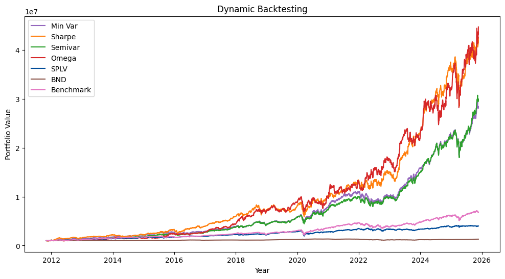

```python
import matplotlib.pyplot as plt

colors = [
    "#9467bd",  # Min Var (morado)
    "#ff7f0e",  # Sharpe (naranja)
    "#2ca02c",  # Semivar (verde)
    "#d62728",  # Omega (rojo)
    "#004c99",  # SPLV (azul)
    "#8c564b",  # BND
    "#e377c2"   # Benchmark
]

plt.figure(figsize=(12, 6))

# Iterate through columns and plot each one with its corresponding color
for i, column_name in enumerate(history.columns):
    plt.plot(history.index, history[column_name], color=colors[i], label=column_name)

plt.title('Dynamic Backtesting')
plt.legend() # This will use the labels set in the loop
plt.xlabel('Year')
plt.ylabel('Portfolio Value')
plt.show()
```

- Min Var es la estrategia más estable y adecuada para un perfil conservador.
- Sharpe y Semivar son balances intermedios entre estabilidad y rendimiento.
- Omega es la más rentable en máximos, pero también la más riesgosa, por lo que no es recomendable para inversionistas adversos al riesgo.

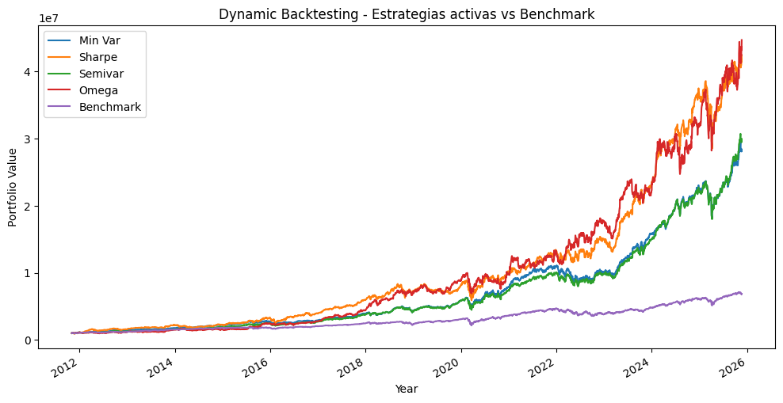

```python
plt.figure(figsize=(12, 6))
history[["Min Var", "Sharpe", "Semivar", "Omega", "Benchmark"]].plot(figsize=(12,6))
plt.title("Dynamic Backtesting - Estrategias activas vs Benchmark")
plt.xlabel("Year")
plt.ylabel("Portfolio Value")
plt.legend()
plt.show()
```

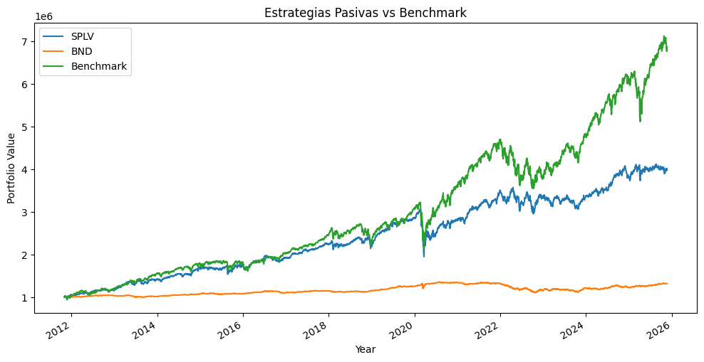

```python
plt.figure(figsize=(12, 6))
history[["SPLV", "BND", "Benchmark"]].plot(figsize=(12,6))
plt.title("Estrategias Pasivas vs Benchmark")
plt.xlabel("Year")
plt.ylabel("Portfolio Value")
plt.legend()
plt.show()
```

## **Métricas de Desempeño**

Es decir, capital inicial, capital final, rendimiento promedio anual, volatilidad anual, Radio de Sharpe, Beta, Treynor, Shortino y Alfa de Jensen

```python
def metricas_desempeno(rets_evol, history, rf):

    metrics = pd.DataFrame(columns=rets_evol.columns)

    # Capital inicial
    metrics.loc['Capital Inicial'] = 1_000_000

    # Capital final
    metrics.loc['Capital Final'] = history.iloc[-1]

    # rendimiento anualizado (promedio x 252)
    metrics.loc['Rendimiento Anual'] = rets_evol.mean() * 252

    # volatilidad anualizada
    metrics.loc['Volatilidad Anual'] = rets_evol.std() * np.sqrt(252)

    # sharpe
    metrics.loc['Sharpe'] = (metrics.loc['Rendimiento Anual'] - rf) / metrics.loc['Volatilidad Anual']

    # downside risk
    downside = rets_evol[rets_evol < 0].fillna(0)
    metrics.loc["Downside Risk"] = downside.std() * np.sqrt(252)

    # upside risk
    upside = rets_evol[rets_evol > 0].fillna(0)
    metrics.loc["Upside Risk"] = upside.std() * np.sqrt(252)

    # Omega
    metrics.loc["Omega"] = metrics.loc["Upside Risk"] / metrics.loc["Downside Risk"]

    # Beta
    benchmark = rets_evol["Benchmark"]
    metrics.loc["Beta"] = rets_evol.apply(lambda x: x.cov(benchmark)) / benchmark.var()

    # Alfa Jensen
    rm = benchmark.mean() * 252
    metrics.loc["Alfa de Jensen"] = metrics.loc["Rendimiento Anual"] - (rf + metrics.loc["Beta"] * (rm - rf))

    # Treynor
    metrics.loc["Treynor"] = (metrics.loc["Rendimiento Anual"] - rf) / metrics.loc["Beta"]

    # Sortino
    metrics.loc["Sortino"] = (metrics.loc["Rendimiento Anual"] - rf) / metrics.loc["Downside Risk"]

    return metrics
```

```python
rets_evol = history.pct_change().dropna()
rets_evol
```

| Date | Min Var | Sharpe | Semivar | Omega | SPLV | BND | Benchmark |
| --- | --- | --- | --- | --- | --- | --- | --- |
| 2011-11-03 | 0.014985 | 0.014242 | 0.018445 | 0.021682 | 0.015323 | -0.002501 | 0.018227 |
| 2011-11-04 | -0.003843 | -0.007021 | -0.002817 | -0.002276 | -0.005560 | 0.001433 | -0.006099 |
| 2011-11-07 | 0.008022 | -0.001274 | 0.015013 | 0.020448 | 0.004393 | 0.000240 | 0.006216 |
| 2011-11-08 | 0.016590 | 0.016261 | 0.011529 | 0.006592 | 0.008748 | -0.003100 | 0.012831 |
| 2011-11-09 | -0.028712 | -0.026955 | -0.023696 | -0.018601 | -0.025226 | 0.001195 | -0.036909 |
| ... | ... | ... | ... | ... | ... | ... | ... |
| 2025-11-17 | -0.007708 | 0.010671 | -0.003321 | 0.031149 | -0.002222 | 0.000539 | -0.009316 |
| 2025-11-18 | -0.003815 | -0.000294 | -0.006218 | -0.002596 | 0.000418 | 0.000809 | -0.008398 |
| 2025-11-19 | 0.012155 | 0.021072 | 0.013123 | 0.030006 | -0.005843 | -0.000404 | 0.003863 |
| 2025-11-20 | -0.013290 | -0.010493 | -0.012874 | -0.011475 | 0.000980 | 0.001482 | -0.015242 |
| 2025-11-21 | 0.010384 | 0.024638 | 0.016107 | 0.035274 | 0.011324 | 0.002421 | 0.009961 |

3534 rows × 7 columns

```python
metrics = metricas_desempeno(rets_evol, history, 0.041)
pd.options.display.float_format = '{:,.4f}'.format
metrics
```

|  | Min Var | Sharpe | Semivar | Omega | SPLV | BND | Benchmark |
| --- | --- | --- | --- | --- | --- | --- | --- |
| Capital Inicial | 1,000,000.0000 | 1,000,000.0000 | 1,000,000.0000 | 1,000,000.0000 | 1,000,000.0000 | 1,000,000.0000 | 1,000,000.0000 |
| Capital Final | 28,376,115.8443 | 42,470,190.7217 | 29,966,496.4204 | 44,721,946.1448 | 4,011,522.7309 | 1,317,490.4665 | 6,828,196.2939 |
| Rendimiento Anual | 0.2576 | 0.2961 | 0.2619 | 0.3061 | 0.1095 | 0.0209 | 0.1512 |
| Volatilidad Anual | 0.1948 | 0.2398 | 0.1970 | 0.2651 | 0.1443 | 0.0494 | 0.1681 |
| Sharpe | 1.1118 | 1.0640 | 1.1215 | 0.9998 | 0.4750 | -0.4070 | 0.6553 |
| Downside Risk | 0.1151 | 0.1422 | 0.1172 | 0.1524 | 0.0937 | 0.0318 | 0.1074 |
| Upside Risk | 0.1254 | 0.1554 | 0.1264 | 0.1751 | 0.0881 | 0.0299 | 0.1031 |
| Omega | 1.0893 | 1.0926 | 1.0784 | 1.1484 | 0.9404 | 0.9387 | 0.9602 |
| Beta | 0.9462 | 0.9925 | 0.9522 | 0.8794 | 0.7005 | 0.0206 | 1.0000 |
| Alfa de Jensen | 0.1123 | 0.1458 | 0.1160 | 0.1682 | -0.0087 | -0.0224 | 0.0000 |
| Treynor | 0.2289 | 0.2570 | 0.2320 | 0.3014 | 0.0978 | -0.9784 | 0.1102 |
| Sortino | 1.8813 | 1.7940 | 1.8854 | 1.7388 | 0.7315 | -0.6324 | 1.0264 |

# Selección del portafolio

### Rebalanceo para estrategia hibrida: 4 portafolios

```python
import pandas as pd
import numpy as np
from pandas.tseries.offsets import DateOffset

def construir_hibrido_con_rebalanceo(
    df,
    col_activa, # Nombre de la columna del portafolio activo (backtest ya hecho)
    col_splv="SPLV", # Nombre de la columna de precios del ETF SPLV
    col_bnd="BND", # Nombre de la columna de precios del ETF BND
    months=6, # Cada cuántos meses se rebalancea el híbrido
    active_prop=0.35, # Proporción total destinada a la parte activa (35%)
    passive_prop=0.65, # Proporción total destinada a la parte pasiva (65%)
    nombre_columna="Hib_35A_65P_50BND_50SPLV",  # Nombre de la nueva columna del portafolio híbrido
    capital_inicial=1_000_000 # Capital inicial del portafolio
):
    # Nos aseguramos de que el índice de fechas esté ordenado
    df = df.sort_index()

    # Calculamos rendimientos diarios de:
    # la estrategia activa (col_activa ya es como si fuera un "activo" más)
    # SPLV
    # BND
    rets_activa = df[col_activa].pct_change().fillna(0)
    rets_splv   = df[col_splv].pct_change().fillna(0)
    rets_bnd    = df[col_bnd].pct_change().fillna(0)

    # Guardamos las fechas y el número de observaciones
    dates = df.index
    n = len(dates)

    # Pesos internos de la parte pasiva:
    # dentro de ese 65%, la mitad SPLV y la mitad BND
    w_splv_pasiva = 0.5
    w_bnd_pasiva  = 0.5

    # Serie donde iremos guardando el valor total del portafolio híbrido en el tiempo
    port_val = pd.Series(index=dates, dtype=float)
    port_val.iloc[0] = capital_inicial   # Día 0: todo el capital inicial

    # Pesos efectivos sobre cada estrategia
    # Activa tiene 35% directo
    w_activa = active_prop
    # SPLV y BND comparten el 65% pasivo
    w_splv   = passive_prop * w_splv_pasiva   # 0.65 * 0.5 = 0.325
    w_bnd    = passive_prop * w_bnd_pasiva    # 0.65 * 0.5 = 0.325

    # Construimos las fechas de rebalanceo
    rebal_dates = []
    current = dates[0]   # Empezamos en la primera fecha
    last = dates[-1]     # Última fecha disponible

    # Vamos avanzando de 'months' en 'months' (por ejemplo, cada 6 meses)
    while current <= last:
        # Buscamos el índice de la fecha "actual" en el índice del DataFrame
        # (o la posición donde debería ir)
        loc = dates.searchsorted(current)
        if loc < n:
            # Guardamos la fecha real del DataFrame más cercana hacia adelante
            rebal_dates.append(dates[loc])
        # Sumamos n meses a la fecha actual
        current = current + DateOffset(months=months)

    # Quitamos posibles duplicados manteniendo el orden
    rebal_dates = sorted(list(dict.fromkeys(rebal_dates)))

    # Asignamos el capital inicial a cada estrategia según los pesos
    cap_activa = port_val.iloc[0] * w_activa
    cap_splv   = port_val.iloc[0] * w_splv
    cap_bnd    = port_val.iloc[0] * w_bnd

    # Recorremos día por día para actualizar el valor del portafolio
    for i in range(1, n):
        d = dates[i]   # fecha actual

        # Si la fecha actual es una fecha de rebalanceo:
        if d in rebal_dates:
            # Calculamos el valor total del portafolio (suma de las tres partes)
            total = cap_activa + cap_splv + cap_bnd
            # Redistribuimos el total respetando los pesos objetivo (35% activa, 32.5% SPLV, 32.5% BND)
            cap_activa = total * w_activa
            cap_splv   = total * w_splv
            cap_bnd    = total * w_bnd

        # Obtenemos los rendimientos del día para cada parte
        r_a = rets_activa.loc[d]
        r_s = rets_splv.loc[d]
        r_b = rets_bnd.loc[d]

        # Actualizamos el capital de cada estrategia multiplicando por (1 + rendimiento)
        cap_activa *= (1 + r_a)
        cap_splv   *= (1 + r_s)
        cap_bnd    *= (1 + r_b)

        # Valor total del portafolio híbrido en esa fecha
        port_val.iloc[i] = cap_activa + cap_splv + cap_bnd

    # Agregamos la serie del portafolio híbrido al DataFrame original
    df[nombre_columna] = port_val

    # Regresamos el DataFrame ya con la nueva columna
    return df
```

```python
df = history.copy()
# Diccionario: columna activa= nombre de la columna híbrida
estrategias = {
    "Min Var":     "Hib_minvar",
    "Omega":      "Hib_omega",
    "Sharpe":     "Hib_sharpe",
    "Semivar": "Hib_minsemivar",

}

for col_activa, col_hib in estrategias.items():
    df = construir_hibrido_con_rebalanceo(
        df=df,
        col_activa=col_activa,
        col_splv="SPLV",
        col_bnd="BND",
        months=6,
        active_prop=0.35,
        passive_prop=0.65,
        nombre_columna=col_hib,
        capital_inicial=1_000_000
    )
```

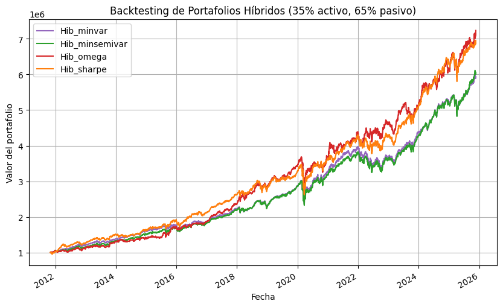

```python
import matplotlib.pyplot as plt

cols_hibridos = ["Hib_minvar", "Hib_minsemivar", "Hib_omega", "Hib_sharpe"]

# Colores del default color cycle de Matplotlib
colors = ["#9467bd", "#2ca02c", "#d62728", "#ff7f0e"]
# minvar, semivar, omega, sharpe (orden como tus columnas)

df[cols_hibridos].plot(
    figsize=(10,6),
    color=colors
)

plt.title("Backtesting de Portafolios Híbridos (35% activo, 65% pasivo)")
plt.ylabel("Valor del portafolio")
plt.xlabel("Fecha")
plt.grid(True)
plt.show()
```

### Comportamiento portafolio hibrido con semivar y diferentes escenarios de estrategia pasiva

```python
import pandas as pd
import numpy as np
from pandas.tseries.offsets import DateOffset

def construir_hibrido_con_rebalanceo(
    df,
    col_activa,
    col_splv="SPLV",
    col_bnd="BND",
    months=6,
    active_prop=0.35,
    passive_prop=0.65,
    nombre_columna="Hib_35A_65P",
    capital_inicial=1_000_000,
    w_splv_pasiva=0.5,   # % de la parte pasiva que va a SPLV
    w_bnd_pasiva=0.5     # % de la parte pasiva que va a BND
):
    # normalizamos a que sumen 1
    total_pasiva = w_splv_pasiva + w_bnd_pasiva
    w_splv_pasiva = w_splv_pasiva / total_pasiva
    w_bnd_pasiva  = w_bnd_pasiva  / total_pasiva

    df = df.sort_index()

    rets_activa = df[col_activa].pct_change().fillna(0)
    rets_splv   = df[col_splv].pct_change().fillna(0)
    rets_bnd    = df[col_bnd].pct_change().fillna(0)

    dates = df.index
    n = len(dates)

    # Pesos efectivos a nivel portafolio (35% activo, 65% pasivo repartido entre ambos)
    w_activa = active_prop
    w_splv   = passive_prop * w_splv_pasiva
    w_bnd    = passive_prop * w_bnd_pasiva

    port_val = pd.Series(index=dates, dtype=float)
    port_val.iloc[0] = capital_inicial

    # Fechas de rebalanceo
    rebal_dates = []
    current = dates[0]
    last = dates[-1]
    while current <= last:
        loc = dates.searchsorted(current)
        if loc < n:
            rebal_dates.append(dates[loc])
        current = current + DateOffset(months=months)
    rebal_dates = sorted(list(dict.fromkeys(rebal_dates)))

    # Capital inicial en cada sleeve
    cap_activa = port_val.iloc[0] * w_activa
    cap_splv   = port_val.iloc[0] * w_splv
    cap_bnd    = port_val.iloc[0] * w_bnd

    for i in range(1, n):
        d = dates[i]

        # Rebalanceo cada 6 meses
        if d in rebal_dates:
            total = cap_activa + cap_splv + cap_bnd
            cap_activa = total * w_activa
            cap_splv   = total * w_splv
            cap_bnd    = total * w_bnd

        r_a = rets_activa.loc[d]
        r_s = rets_splv.loc[d]
        r_b = rets_bnd.loc[d]

        cap_activa *= (1 + r_a)
        cap_splv   *= (1 + r_s)
        cap_bnd    *= (1 + r_b)

        port_val.iloc[i] = cap_activa + cap_splv + cap_bnd

    df[nombre_columna] = port_val
    return df
```

```python
# OJO: ajusta "Activa_minsemivar" al nombre REAL de tu columna de min semivar
col_activa_minsemivar = "Semivar"   # por ejemplo "Semivar"

escenarios = {
    "Hib_semivar_50SPLV_50BND": (0.5, 0.5),
    "Hib_semivar_30SPLV_70BND": (0.3, 0.7),
    "Hib_semivar_70SPLV_30BND": (0.7, 0.3),
    "Hib_semivar_0SPLV_100BND": (0.0, 1.0),
    "Hib_semivar_100SPLV_0BND": (1.0, 0.0),
    "Hib_semivar_40SPLV_60BND": (0.4, 0.6),
}

for nombre_columna, (w_splv_pasiva, w_bnd_pasiva) in escenarios.items():
    df = construir_hibrido_con_rebalanceo(
        df=df,
        col_activa=col_activa_minsemivar,
        col_splv="SPLV",
        col_bnd="BND",
        months=6,
        active_prop=0.35,
        passive_prop=0.65,
        nombre_columna=nombre_columna,
        capital_inicial=1_000_000,
        w_splv_pasiva=w_splv_pasiva,
        w_bnd_pasiva=w_bnd_pasiva
    )
```

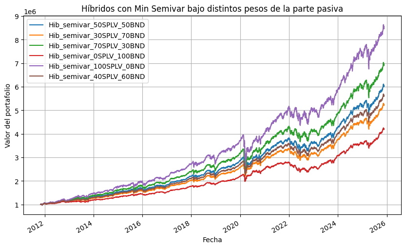

```python
import matplotlib.pyplot as plt

cols_escenarios = list(escenarios.keys())

df[cols_escenarios].plot(figsize=(10, 6))
plt.title("Híbridos con Min Semivar bajo distintos pesos de la parte pasiva")
plt.xlabel("Fecha")
plt.ylabel("Valor del portafolio")
plt.grid(True)
plt.show()
```

## Benchmark vs portafolio seleccionado

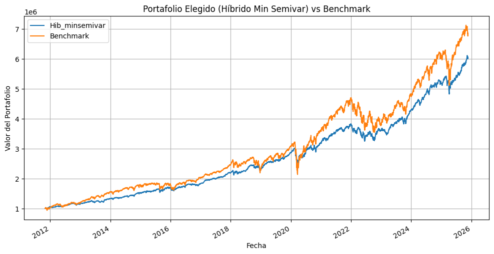

```python
plt.figure(figsize=(12,6))
df[["Hib_minsemivar", "Benchmark"]].plot(figsize=(12,6))
plt.title("Portafolio Elegido (Híbrido Min Semivar) vs Benchmark")
plt.ylabel("Valor del Portafolio")
plt.xlabel("Fecha")
plt.grid(True)
plt.show()
```

### Rendimiento y Volatilidad del portafolio híbrido

#### Semivar

```python
def opt_semivar_target (tickers: list, benchmark: str, start: str , end: str ) -> np.array :
  prices = yf.download(tickers, start=start, end=end, progress = False )['Close']
  benchmark=yf.download(benchmark, start=start, end=end)['Close']

  rend = prices.pct_change().dropna()
  rend_mean = rend.mean()

  corr = rend.corr()

  rend_benchmark = benchmark.pct_change().dropna()

  diffs = rend - rend_benchmark.values
  bellow_zero_target = diffs[diffs<0].fillna(0)
  target_downside= np.array(bellow_zero_target.std())

  n_act = len(tickers)
  target_matrix =(target_downside.reshape(n_act, 1) @ target_downside.reshape(1, n_act)* corr)


  def semivarianza_target (w):
    return w.T @ target_matrix @ w

  n = len(tickers)
  w_inicial = np.ones(n) / n

  restricciones = lambda w: np.sum(w) - 1

  cotas = [(0,1)]*n

  tol = 1e-20

  return minimize( fun = semivarianza_target, x0 = w_inicial, bounds = cotas, constraints= {'fun': restricciones, 'type': 'eq'}, tol = tol )
```

#### Rendimiento Histórico

```python
ticker_estr_activa = ['AAPL', 'AMZN', 'GOOGL', 'JPM', 'LLY']
w_optimizada_activa = opt_semivar_target(ticker_estr_activa, 'SPY' ,start='2010-01-01', end='2025-07-01').x

portafolio = ['AAPL', 'AMZN', 'GOOGL', 'JPM', 'LLY', "SPY"]
prices = yf.download(portafolio, start='2010-01-01', end='2025-11-24')["Close"]

resultados = dict(zip(prices.columns, w_optimizada_activa*100))
resultados
```

```
{'AAPL': np.float64(18.501128910117497),
 'AMZN': np.float64(3.20156353657622),
 'GOOGL': np.float64(20.982763973694716),
 'JPM': np.float64(35.93881772554811),
 'LLY': np.float64(21.375725854063464)}
```

Estos pesos son los optimizados considerando los 15 años, como si fuera estático

```python
# Convertirlo en DataFrame
pesos = pd.DataFrame.from_dict(resultados, orient='index', columns=['pesos'])
pesos
```

|  | pesos |
| --- | --- |
| AAPL | 18.501129 |
| AMZN | 3.201564 |
| GOOGL | 20.982764 |
| JPM | 35.938818 |
| LLY | 21.375726 |

La estrategia pasiva representa el 65% del portafolio y se compone del 50% del SPLV y 50% del BND que se rebalancean según el ciclo económico

```python
# Tickers
active_tickers = ['AAPL', 'AMZN', 'GOOGL', 'JPM', 'LLY']
passive_tickers = ['BND', 'SPLV']
tickers = active_tickers + passive_tickers

# Descargar datos
rend = yf.download(tickers, start='2010-01-01', end='2025-11-24')["Close"].pct_change().dropna()

# Proporciones
active_prop = 0.35
passive_prop = 0.65

# Pesos activos optimizados
w_activos = pd.Series(w_optimizada_activa, index=active_tickers)

# Pesos pasivos (50/50)
w_pasivos = pd.Series([0.5, 0.5], index=passive_tickers)

# Combinar todo en un vector de pesos total
w_total = pd.concat([
    w_activos * active_prop,
    w_pasivos * passive_prop
])

# Asegurar orden
w_total = w_total.loc[tickers]

# Calcular rendimiento del portafolio híbrido
rend_port_hibrido = (rend.mul(w_total, axis=1).sum(axis=1) * 252).mean()
rend_port_hibrido*100
```

```
np.float64(12.758236161440076)
```

```python
# Matriz de covarianzas diarias
cov = rend.cov()

# Volatilidad diaria
port_vol_diaria = np.sqrt(w_total.T @ cov @ w_total)

# Anualizar
port_vol_anual = port_vol_diaria * np.sqrt(252)

# A porcentaje
port_vol_anual_pct = port_vol_anual * 100

print(f"Volatilidad anual: {port_vol_anual_pct:.2f}%")
```

```
Volatilidad anual: 11.13%
```

```python
# DATAFRAME CON VOLATILIDAD Y RENDIMIENTO DEL PORTAFOLIO
vol_rend = pd.DataFrame({
    "Rendimiento": [rend_port_hibrido*100],
    "Volatilidad": [port_vol_anual_pct]
})

vol_rend
```

|  | Rendimiento | Volatilidad |
| --- | --- | --- |
| 0 | 12.758236 | 11.128504 |

La semivarianza de la estrategia activa es muy baja

```python
opt_semivar_target(ticker_estr_activa, "SPY", start='2010-01-01', end='2025-11-24').fun
```

```
np.float64(3.044739154189135e-05)
```

```python
import numpy as np
import yfinance as yf
import pandas as pd

def semivar_portafolio_hibrido(tickers: list,
                               benchmark: str,
                               weights: np.array,
                               start: str,
                               end: str,
                               annualize: bool = False) -> float:

    # Descargamos precios de los activos
    prices = yf.download(tickers, start=start, end=end, progress=False)['Close']
    # Benchmark
    benchmark_prices = yf.download(benchmark, start=start, end=end, progress=False)['Close']

    # Rendimientos diarios
    rend = prices.pct_change().dropna()
    rend_benchmark = benchmark_prices.pct_change().dropna()

    # Alineamos benchmark y activos
    rend, rend_benchmark = rend.align(rend_benchmark, join='inner', axis=0)

    # Diferencias activo - benchmark
    diffs = rend.sub(rend_benchmark.values, axis=0)

    # Rendimientos abajo de cero
    bellow_zero_target = diffs[diffs < 0].fillna(0)

    # Desviaciones estándar de downside por activo
    target_downside = np.array(bellow_zero_target.std())

    # Matriz de correlaciones entre activos
    corr = rend.corr()

    # Matriz tipo covarianza de downside
    n_act = len(tickers)
    target_matrix = (target_downside.reshape(n_act, 1)
                     @ target_downside.reshape(1, n_act) * corr)

    # Vector de pesos en forma numpy
    w = np.array(weights, dtype=float)

    # Semivarianza del portafolio (diaria)
    semivar_port = float(w.T @ target_matrix @ w)

    # anualizar
    if annualize:
        semivar_port *= 252

    return semivar_port
```

```python
active_tickers = ['AAPL', 'AMZN', 'GOOGL', 'JPM', 'LLY']
passive_tickers = ['BND', 'SPLV']
tickers = active_tickers + passive_tickers

active_prop = 0.35
passive_prop = 0.65

w_activos = pd.Series(w_optimizada_activa, index=active_tickers)
w_pasivos = pd.Series([0.5, 0.5], index=passive_tickers)

w_total = pd.concat([
    w_activos * active_prop,
    w_pasivos * passive_prop
])

w_total = w_total.loc[tickers]
```

```python
semivar_hibrido = semivar_portafolio_hibrido(
    tickers=tickers,
    benchmark='SPY',
    weights=w_total.values,
    start='2010-01-01',
    end='2025-11-24',
    annualize=True   # True si la quieres anualizada
)

print("Semivarianza anual del portafolio híbrido:", semivar_hibrido)
```

```
Semivarianza anual del portafolio híbrido: 0.00574725712276191
```

### Invertir hoy

```python
#  DEFINIR ACTIVOS, PASIVOS Y BENCHMARK

months = 6  # periodo de rebalanceo
rf = 0.041 # tasa libre de riesgo anual
capital = 1_000_000 # capital inicial

# Activos activos (solo estos entran a la optimización)
active_tickers = ['AAPL', 'AMZN', 'GOOGL', 'JPM', 'LLY']

# Activos pasivos (estos van en la parte 65%)
passive_tickers = ['BND', 'SPLV']

# Solo la estrategia activa se optimiza y usa spy como su benchmark
prices_activos = prices[active_tickers].copy()

# benchmark
prices_spy = Benchmark.copy()


# OBTENER ÚLTIMA VENTANA (6 MESES)

n_days = int(252 * (months / 12))   # 126 días hábiles

window_activos = prices_activos.iloc[-n_days:, :]
window_spy     = prices_spy.iloc[-n_days:, :]

rets_window = window_activos.pct_change().dropna()
rets_spy    = window_spy.pct_change().dropna()


# OPTIMIZAR LA PARTE ACTIVA (SEMIVAR)

optimizer = OptimizePortfolioWeights(returns=rets_window, risk_free=rf)

# Solo optimiza sobre los 5 activos, usando el benchmark SPY solo para downside
w_semivar_final = optimizer.opt_min_semivar(rets_spy)

# Serie limpia con NOMBRES correctos
w_activos_final = pd.Series(w_semivar_final, index=active_tickers)

# CONVERTIR A PORTAFOLIO HÍBRIDO
# (35% activo, 65% pasivo)

active_prop = 0.35
passive_prop = 0.65

# Parte activa (Semivar)
w_activos_hoy = w_activos_final * active_prop

# Parte pasiva (igual 50/50)
w_pasivos_hoy = pd.Series({"BND": 0.5, "SPLV": 0.5}) * passive_prop

# Combinar
w_total_hoy = pd.concat([w_activos_hoy, w_pasivos_hoy])

# Normalizar
w_total_hoy = w_total_hoy / w_total_hoy.sum()


#  TABLA FINAL CON PESOS, MONTOS y ACCIONES

all_tickers_for_final_table = w_total_hoy.index.tolist()
prices_total = yf.download(all_tickers_for_final_table, start='2010-01-01', end='2025-11-24')['Close']

precios_actuales = prices_total.iloc[-1][w_total_hoy.index]   # prices_total incluye todos los tickers

monto_invertido = w_total_hoy * capital
acciones = (monto_invertido / precios_actuales).apply(np.floor)

tabla_final = pd.DataFrame({
    "Peso final": w_total_hoy*100,
    "Monto invertido": monto_invertido,
    "Precio actual": precios_actuales,
    "Acciones a comprar": acciones
})

tabla_final
```

|  | Peso final | Monto invertido | Precio actual | Acciones a comprar |
| --- | --- | --- | --- | --- |
| AAPL | 16.592670 | 165926.698616 | 271.489990 | 611.0 |
| AMZN | 0.977668 | 9776.675537 | 220.690002 | 44.0 |
| GOOGL | 5.249185 | 52491.853394 | 299.660004 | 175.0 |
| JPM | 9.731434 | 97314.337249 | 298.019989 | 326.0 |
| LLY | 2.449044 | 24490.435204 | 1059.699951 | 23.0 |
| BND | 32.500000 | 325000.000000 | 74.519997 | 4361.0 |
| SPLV | 32.500000 | 325000.000000 | 72.205994 | 4501.0 |

**Portafolio Seleccionado:** Con base en las métricas de desempeño y dado el perfil del inversionista, averso al riesgo y con horizonte de largo plazo, se seleccionó el portafolio Híbrido Min Semivar, que combina una estrategia activa basada en minimización de semivarianza con una parte pasiva diversificada entre BND y SPLV.

**Última ventana disponible:** Para determinar los pesos con los que invertir hoy, se utilizó la última ventana de 6 meses, que es el periodo de rebalanceo definido en el backtesting. Al optimizar la parte activa con esta información reciente, el modelo asigna mayor peso a AAPL, GOOGL y JPM, manteniendo una exposición controlada al downside. La parte pasiva mantiene una asignación del 65%, dividida equitativamente entre BND y SPLV ya que esto concuerda con el ciclo económico actual.

**Ponderaciones finales:** Las ponderaciones finales del portafolio resultan en una inversión de USD 1,000,000 distribuida entre 7 instrumentos. Esto genera un total de 1 179 acciones en instrumentos activos y 8 862 acciones en los ETFs pasivos. La composición final refleja un balance adecuado entre rendimiento esperado y control de riesgo, acorde al perfil del inversionista.

# **Conclusión**

El análisis comparativo de las cuatro estrategias activas evaluadas a lo largo del proyecto permitió identificar cuál de ellas se ajusta mejor al perfil del inversionista definido, caracterizado por una alta aversión al riesgo y un horizonte de inversión de largo plazo. Aunque todas las estrategias presentan ventajas particulares, la estrategia basada en semivarianza demostró ser la alternativa más adecuada para equilibrar estabilidad y rendimiento. Su mayor beneficio es que no trata a todos los riesgos de la misma manera; pone mayor énfasis en los movimientos negativos del mercado y penaliza de forma más estricta los comportamientos de pérdidas, que son precisamente los escenarios que un inversionista conservador desea minimizar.

La implementación del portafolio final bajo un esquema híbrido, asignando 35% a la parte activa y 65% a la parte pasiva distribuida entre BND y SPLV, permitió reforzar la estabilidad del portafolio sin renunciar al potencial de crecimiento. La parte pasiva actúa como un amortiguador frente a escenarios adversos, mientras que la parte activa contribuye a capturar oportunidades de rendimiento dentro de un marco de riesgo controlado. Esta combinación demostró un perfil de riesgo-rendimiento más equilibrado que las alternativas puramente activas.

Finalmente, se utilizaron los últimos seis meses de información, correspondientes con el periodo de rebalanceo definido desde el inicio, para determinar las ponderaciones actuales del portafolio. Estas ponderaciones se convirtieron posteriormente en montos y número de acciones, obteniendo así una cartera implementable con el capital disponible. El resultado es un portafolio diversificado, robusto y alineado con los objetivos del inversionista, que busca preservar capital, evitar caídas pronunciadas y al mismo tiempo, participar de manera racional en el crecimiento del mercado a lo largo del tiempo.

**Referencias**

Alphabet Inc. (2025, April 24). Alphabet Reports First Quarter 2025 Results. U.S. Securities and Exchange Commission. Recuperado de: https://abc.xyz/assets/34/fa/ee06f3de4338b99acffc5c229d9f/2025q1-alphabet-earnings-release.pdf

Alphabet Inc. (2025, July 23). Alphabet Reports Second Quarter 2025 Results. U.S. Securities and Exchange Commission. Recuperado de: https://abc.xyz/assets/cc/27/3ada14014efbadd7a58472f1f3f4/2025q2-alphabet-earnings-release.pdf

Amazon.com, Inc. (2025, May 1). Amazon.com Announces First Quarter Results. Business Wire. Recuperado de: https://ir.aboutamazon.com/news-release/news-release-details/2025/Amazon-com-Announces-First-Quarter-Results/default.aspx

Amazon.com, Inc. (2025, July 31). Amazon.com Announces Second Quarter Results. Business Wire. Recuperado de: https://ir.aboutamazon.com/news-release/news-release-details/2025/Amazon-com-Announces-Second-Quarter-Results/default.aspx

Apple Inc. (2025). Apple reports second quarter results en Apple Newsroom. https://www.apple.com/newsroom/2025/05/apple-reports-second-quarter-results/

Bloomberg. (2025). Communication Services Sector: Performance. Recuperado de: https://www.bloomberg.com/markets/sectors/communication-services

Bostic, R. (2025).Weighing the Risks: Why Inflation Tips the Scales. Federal Reserve Bank of Atlanta Recuperado de: Weighing the Risks: Why Inflation Tips the Scales - November 12, 2025 - Federal Reserve Bank of Atlanta

Cbonds. (2025). Vanguard Total Bond Market ETF (BND): ETF distribution schedule. Recuperado de https://cbonds.com/etf/2164/

Companies Market Cap. (2025). JPMorgan Chase (JPM) – Revenue en Companies MarketCap. Recuperado de: https://companiesmarketcap.com/jp-morgan-chase/revenue/

Deloitte. (2025, February). 2025 Technology Industry Outlook en Deloitte Insights. Recuperado de: https://www.deloitte.com/us/en/insights/industry/technology/technology-industry-outlook.html

Eli Lilly and Company. (2025 ). Lilly reports full Q4 2024 financial results and provides 2025 guidance en Eli Lilly and Company. Recuperado de: https://investor.lilly.com/news-releases/news-release-details/lilly-reports-full-q4-2024-financial-results-and-provides-2025

Eli Lilly and Company. (2024). Annual report 2024 en Eli Lilly and Company. Recuperado de: https://investor.lilly.com/financial-information/annual-reports

Eli Lilly and Company. (2025 ). Lilly provides an update on 2024 revenue guidance, announces 2025 revenue guidance en PR Newswire. Recuperado de : https://www.prnewswire.com/news-releases/lilly-provides-update-on-2024-revenue-guidance-announces-2025-revenue-guidance-302349776.html

Eli Lilly and Company. (2025). Eli Lilly (LLY) – Revenue (Companies Market Cap) en Eli Lilly and Company. Recuperado de: https://companiesmarketcap.com/eli-lilly/revenue/

Eli Lilly and Company. (2025 ). Interactive financials – Income Statement (2020-2024) en Eli Lilly and Company. Recuperado de: https://investor.lilly.com/financial-information/fundamentals/income-statement

ETF Database. (2025). Invesco S&P 500 Low Volatility ETF (SPLV) profile and holdings. Recuperado de https://etfdb.com/etf/SPLV/

ETF Database. (2025). Vanguard Total Bond Market ETF (BND) profile and holdings. Recuperado de https://etfdb.com/etf/BND/

Fierce Pharma. (2025). Eli Lilly logs massive Q4 revenue jump—but it’s not just thanks to en Fierce Pharma. Recuperado de: https://www.fiercepharma.com/pharma/eli-lillys-very-beatable-2025-guidance-should-ease-investor-sentiment-after-recent-glp-1

Gayed, M. ( 2025 ). Should The Fed Cut Rates? The Truth Behind Sticky Inflation. Led Lag Report. Recuperado de: Should The Fed Cut Rates? The Truth Behind Sticky Inflation

Goldman Sachs. ( 2024 ). Late-Cycle Opportunities, Lingering Tail Risks. Goldman Sach. Recuperado de: Late-Cycle Opportunities, Lingering Tail Risks - Goldman Sachs Asset Management

Gourinchas, P. ( 2025 ). Global Economic Outlook Shows Modest Change Amid Policy Shifts and Complex Forces. International Monetary Fund. Recuperado de. Global Economic Outlook Shows Modest Change Amid Policy Shifts and Complex Forces

Grand View Research. (2025). U.S. IT Services Market Report en Grand View Research. Recuperado de: https://www.grandviewresearch.com/industry-analysis/us-it-services-market-report

Invesco. (2025). Invesco S&P 500 Low Volatility ETF overview. Recuperado de https://www.invesco.com/us/financial-products/etfs/product-detail?audienceType=Investor&ticker=SPLV

Investopedia. (2024). What Is the Consumer Discretionary Sector? En Investopedia. Recuperado de: https://www.investopedia.com/articles/markets/050416/consumer-discretionary-sector-industries-snapshot.asp

Interactive Brokers. (2024). Communication Services Sector – Trading Lesson en Interactive Brokers. Recuperado de: https://www.interactivebrokers.com/campus/trading-lessons/communications-services-sector/

JPMorgan Chase & Co. (2025). 2024 annual report en JPMorgan Chase & Co. Recuperado de: https://www.jpmorganchase.com/ir/annual-report

JPMorgan Chase & Co. (2025). Annual Reports & Proxy Statements en JPMorgan Chase & Co. Recuperado de: https://www.jpmorganchase.com/ir

JPMorgan Chase & Co. (2025). JPMorgan Chase publishes 2024 annual report, including chairman & CEO letter to shareholders en JPMorgan Chase & Co. Recuperado de: https://jpmorganchaseco.gcs-web.com/news-releases/news-release-details/jpmorganchase-publishes-2024-annual-report-including-chairman

Krauskpof, J.( 2025 ). Relentless US stocks rally could teeter on inflation, earnings, valuation risks. Reuters. Recuperado de: Relentless US stocks rally could teeter on inflation, earnings, valuation risks | Reuters

Macrotrends. (2025). Eli Lilly annual revenue 2011-2025 en Macrotrends. Recuperado de: https://www.macrotrends.net/stocks/charts/LLY/eli-lilly/revenue

Macrotrends. (2025). Apple Revenue 2010-2025 | AAPL. Recuperado de: https://www.macrotrends.net/stocks/charts/AAPL/apple/revenue

Mordor Intelligence. (2025). United States E-Commerce Market Size & Forecast (2025-2030). Recuperado de: https://www.mordorintelligence.com/industry-reports/united-states-ecommerce-market

Morgan Stanley. ( 2025 ). Is 2025 (finally) the Year of the Bond?. Morgan Stanley Investment Management. Recuperado de Is 2025 (finally) the Year of the Bond?

Shutte B. (2024 ). Why Sticky Inflation Is Making Things Difficult for the Fed. Northwestern Mutual. Recuperado de: Why Sticky Inflation Is Making Things Difficult for the Fed | Northwestern Mutual

United Nations Conference on Trade and Development. (2025). Trade and Development Foresights 2025. United Nations. Recuperado de: Trade and development foresights 2025: Under pressure – uncertainty reshapes global economic prospects | UN Trade and Development (UNCTAD)

Vanguard. ( 2025 ). Our investment and economic outlook, January 2025. Vanguard. Recuperado de: Our investment and economic outlook, January 2025 | Vanguard

Vanguard. (2025). Vanguard Total Bond Market ETF (BND) overview. Vanguard Group Inc. Recuperado de https://investor.vanguard.com/investment-products/etfs/profile/bnd

Vanguard Institutional. (2025). Vanguard Total Bond Market ETF (BND) – portfolio & duration data. Vanguard Group Inc. Recuperado de https://institutional.vanguard.com/investment-products/etfs/bnd

Yahoo Finance. (2025). Apple Inc. (AAPL) Valuation Measures & Financial Statistics en Yahoo Finance. Recuperado de: https://finance.yahoo.com/quote/AAPL/key-statistics/

Yahoo Finance. (2025). Invesco S&P 500 Low Volatility ETF (SPLV) stock performance and risk metrics. Recuperado de https://finance.yahoo.com/quote/SPLV